# What Makes an Airbnb Premium? Machine Learning Analysis of Melbourne Listings

Joel John Kurien (540666979) | Qilong Zou (550542832) | Subhamay Ghosh (550535650)) | Victor Kibisu Alusa (540921269) | Wengan Li (510010137)

November 01, 2025

# 1 Problem Definition

## 1.1 Research question

To what extent can machine learning identify the key differentiators between Budget, Standard, and Premium Airbnb listings in Melbourne Australia, and which property and host characteristics are the most influential drivers of this classification?

This project is a multiclass classification problem. We are predicting a target variable, price_tier, which has three discrete categories: Budget, Standard and Premium. The goal of our model is to learn the patterns from the various features of the listings and then assign a new, unseen listing to one of these three predefined classes. This is fundamentally different from a regression problem, where we would be predicting the exact dollar price.

## 1.2 Why does it matter, and how does it connect to Sydney/Australia?

This investigation has significant practical relevance for hosts, guests, and policymakers in major Australian tourism hubs like Melbourne and Sydney. By simplifying the price structure into three intuitive tiers, the insights become far more actionable:

**For Hosts and Property Investors**: For a host in a competitive market like Sydney, understanding what separates a ‘Standard’ property from a ‘Premium’ one is crucial. Our model can highlight which specific features (e.g., professional photos, a dedicated workspace, superhost status) provide the best return on investment to move a listing into a higher price tier.

**For Consumers (Travelers)**: The classification provides clarity for tourists. It helps them understand the value proposition of listings in cities like Sydney and Melbourne, allowing them to easily filter for properties that match their budget and expectations for quality.

**For Urban Planning and Market Analysis**: For local councils and tourism bodies, analyzing the distribution and characteristics of ‘Budget’ versus ‘Premium’ listings can reveal patterns about neighbourhood development, gentrification, and the overall health of the short-term rental market. This is a key issue in Sydney, where the impact of Airbnb on housing affordability is a constant topic of debate.

**Revenue optimisation**: Sydney hosts face the nation’s sharpest occupancy decline (-12 % YoY, AirDNA 2024). A reliable Budget/Standard/Premium flag lets new hosts benchmark against comparable stock and adjust pricing or amenities quickly.

# 2 Data Description

## 2.1 Data Sources

- Primary Dataset: Melbourne Airbnb listings, obtained from OpenML (OpenML, n.d.) (download: Kaggle (TylerX, n.d.), original source: insideairbnb (Inside Airbnb, n.d.))
- Publication: (Shi et al., 2021) benchmarked multimodal AutoML methods for tabular data with text fields.

## 2.2 Data Composition

```r
# -------------------------------
# Load dataset
# -------------------------------
airbnb_data <- read.arff("dataset_")

# Convert character columns to factors
char_cols <- sapply(airbnb_data, is.character)
airbnb_data[char_cols] <- lapply(airbnb_data[char_cols], as.factor)

# Ensure target variable is factor
if ("price_label" %in% names(airbnb_data)) {
  airbnb_data$price_label <- as.factor(airbnb_data$price_label)
}

airbnb_data <- airbnb_data %>% select(-c(space, description, summary))

# Display as interactive scrollable table
datatable(
  airbnb_data[1:5,],
  options = list(
    pageLength = 1,       # show 1 rows per page
    scrollX = TRUE,        # horizontal scroll
    scrollY = "100px"      # vertical scroll with fixed height
  )
)
```

|  | id | listing_url | scrape_id | last_scraped | name | neighborhood_overview | notes | transit | access | interaction | house_rules | picture_url | host_id | host_url | host_name | host_since | host_location | host_about | host_response_time | host_response_rate | host_is_superhost | host_thumbnail_url | host_picture_url | host_neighborhood | host_verifications | host_has_profile_pic | host_identity_verified | street | neighborhood | … |
| --- | --- | --- | --- | --- | --- | --- | --- | --- | --- | --- | --- | --- | --- | --- | --- | --- | --- | --- | --- | --- | --- | --- | --- | --- | --- | --- | --- | --- | --- | --- |
| 1 | 25586695 | "https://www.airbnb.com/rooms/25586695" | 20181200000000 | "12/7/2018" | "Beach side, art deco flat in heart of St Kilda" |  |  |  |  |  |  | "https://a0.muscache.com/im/pictures/c859fd29-0439-4726-8801-f35f5a49dda6.jpg?aki_policy=large" | 37536766 | "https://www.airbnb.com/users/show/37536766" | "Ben" | "7/5/2015" | "Melbourne, Victoria, Australia" |  |  |  | "f" | "https://a0.muscache.com/im/users/37536766/profile_pic/1436091426/original.jpg?aki_policy=profile_small" | "https://a0.muscache.com/im/users/37536766/profile_pic/1436091426/original.jpg?aki_policy=profile_x_medium" | "St Kilda" | "['email', 'phone', 'facebook', 'reviews', 'jumio', 'government_id']" | "t" | "t" | "Saint Kilda, VIC, Australia" | "St Kilda" | … |
| 2 | 1057401 | "https://www.airbnb.com/rooms/1057401" | 20181200000000 | "12/7/2018" | "Modern Bayside Studio Apartment" | "The apartment is in a quiet residential neighbourhood, one block from local shops and cafes, a short walk to a swimming pool and gym, the beach is within walking distance." |  | "There is street parking available outside at no cost, there is a bus which goes to Mordialloc one way and Southland shopping mall the other 3 minutes walk away and a train station with trains to the … | "The apartment is fully self-contained and private for your exclusive use during your stay. There is also a small outside deck with chairs and table." | "We will leave you completely alone to enjoy your stay, you are welcome to ring our doorbell or call us on the phone any time during the day." | "Please do not smoke in the flat or garden. This is a studio flat, so the maximum number of persons that may be accommodated at the property is two adults, although we can squeeze a baby or toddler in… | "https://a0.muscache.com/im/pictures/15905558/3e17dd27_original.jpg?aki_policy=large" | 5824112 | "https://www.airbnb.com/users/show/5824112" | "Fiona" | "4/8/2013" | "Victoria, Australia" | "My family love traveling and have explored many countries and enjoy camping and boating near to our home in Melbourne. We relish in meeting people from all cultures and try to make our guests feel ve… | "within an hour" | "100%" | "t" | "https://a0.muscache.com/im/users/5824112/profile_pic/1403840387/original.jpg?aki_policy=profile_small" | "https://a0.muscache.com/im/users/5824112/profile_pic/1403840387/original.jpg?aki_policy=profile_x_medium" |  | "['email', 'phone', 'reviews', 'jumio', 'offline_government_id', 'selfie', 'government_id', 'identity_manual']" | "t" | "f" | "Mordialloc, VIC, Australia" |  | … |
| 3 | 24949385 | "https://www.airbnb.com/rooms/24949385" | 20181200000000 | "12/7/2018" | "Spacious Saint kilda home with a View" |  |  |  |  |  | "Guests should clean after themselves accordingly" | "https://a0.muscache.com/im/pictures/fc7453dd-478c-4844-9a28-4a8929e5f0d7.jpg?aki_policy=large" | 60184806 | "https://www.airbnb.com/users/show/60184806" | "Norbert" | "2/24/2016" | "Prahran, Victoria, Australia" |  | "a few days or more" | "0%" | "f" | "https://a0.muscache.com/im/pictures/c8d9e09a-fdbc-4a66-a015-4c6dbacf5a34.jpg?aki_policy=profile_small" | "https://a0.muscache.com/im/pictures/c8d9e09a-fdbc-4a66-a015-4c6dbacf5a34.jpg?aki_policy=profile_x_medium" | "St Kilda" | "['email', 'phone', 'facebook', 'reviews', 'jumio', 'government_id']" | "t" | "t" | "Saint Kilda, VIC, Australia" | "St Kilda" | … |
| 4 | 20075093 | "https://www.airbnb.com/rooms/20075093" | 20181200000000 | "12/7/2018" | "Rewarding Richmond Location-Outstanding Apartment!" | "Richmond is one of the most vibrant and diverse areas in Melbourne. It is the quintessential suburb for inner city living and has prime access to social and sporting activities. Nestled between Colli… | "Please remove your shoes whilst inside, as there are floorboards and the noise travels directly below to the neighbours underneath. Thank you kindly." | "To go directly into the CBD just walk 200 metres to Coppin Street – Stop 20. From here take the # 75 Tram (Vermont South to Etihad Stadium Docklands) or the #48 (North Balwyn to Victoria Harbour Dock… | "Guests will have access to the entire property" | "I am available to answer any questions, queries or issues as they arise during your stay." |  | "https://a0.muscache.com/im/pictures/aca23282-4eea-49ef-861a-5b55bb090b7e.jpg?aki_policy=large" | 136850205 | "https://www.airbnb.com/users/show/136850205" | "Fabrice" | "6/25/2017" | "Melbourne, Victoria, Australia" |  | "within an hour" | "100%" | "f" | "https://a0.muscache.com/im/pictures/19e7ebdd-aa35-4fac-98f8-c180fb3c63b3.jpg?aki_policy=profile_small" | "https://a0.muscache.com/im/pictures/19e7ebdd-aa35-4fac-98f8-c180fb3c63b3.jpg?aki_policy=profile_x_medium" | "Richmond" | "['email', 'facebook', 'reviews', 'jumio', 'offline_government_id', 'government_id']" | "t" | "f" | "Richmond, VIC, Australia" | "Richmond" | … |
| 5 | 16275657 | "https://www.airbnb.com/rooms/16275657" | 20181200000000 | "12/7/2018" | "Close to the centre of Melbourne." | "Double story townhouse. Host has own space upstairs but will be absent. Guests have 2 bedrooms and their own bathroom upstairs. Downstairs with an entertainment unit in one space and a sitting room i… |  | "Easy public transport system, close by. - trams or bus. Can park safely on the street outside." | "2 Bedrooms 4 People maximum stay/ 3nights minimum stay. Own bathroom and toilet Use of all living space." | "Complete privacy." | "Negotiations regarding time of stay encouraged. Cleaning can be readily organised for long stats." | "https://a0.muscache.com/im/pictures/30562e3b-7745-4d27-896e-70c626790a5e.jpg?aki_policy=large" | 106450710 | "https://www.airbnb.com/users/show/106450710" | "Jennifer" | "12/6/2016" | "Victoria, Australia" | "Single, work lots. Enjoy other people for short stays!" | "within a few hours" | "100%" | "f" | "https://a0.muscache.com/im/pictures/b5893e90-ad51-4473-97d5-dfa31e368163.jpg?aki_policy=profile_small" | "https://a0.muscache.com/im/pictures/b5893e90-ad51-4473-97d5-dfa31e368163.jpg?aki_policy=profile_x_medium" |  | "['phone', 'facebook', 'reviews']" | "t" | "f" | "Princes Hill, VIC, Australia" | "Carlton North" | … |

```r
# -------------------------------
# Missingness plot (top 10 cols)
# -------------------------------
total_missing <- sum(is.na(airbnb_data))
missing_top10 <- sort(colSums(is.na(airbnb_data)), decreasing = TRUE)[1:10]

missing_df <- data.frame(
  Column = names(missing_top10),
  Missing = as.numeric(missing_top10)
)

missingness_plot <- ggplot(missing_df, aes(x = reorder(Column, Missing), y = Missing)) +
  geom_col(fill = "#E69F00") +
  coord_flip() +
  labs(
    title = "Top 10 Columns with Missing Values",
    x = "",
    y = "Number of Missing Values"
  ) +
  theme_minimal(base_size = 12) +
  theme(
    plot.title = element_text(face = "bold", size = 14),
    panel.grid = element_blank(),       # removes all grid lines
    panel.background = element_blank(), # removes background
    axis.line = element_line(color = "black"),  # adds clean axes lines
    axis.ticks = element_line(color = "black")  # show ticks
  )

# -------------------------------
# Target Histogram
# -------------------------------
target_histogram <- ggplot(airbnb_data, aes(x = price_label)) +
  geom_bar(fill = "#E69F00") +
  geom_text(stat='count', aes(label=..count..), vjust=1, size=3.5, color = "white") +
  labs(
    title = "Target Class Distribution",
    x = "Price Category",
    y = ""
  ) +
  theme_minimal(base_size = 12) +
  theme(
    plot.title = element_text(face = "bold", size = 14),
    panel.grid = element_blank(),       # removes all grid lines
    panel.background = element_blank(), # removes background
    axis.line = element_line(color = "black"),  # adds clean axes lines
    axis.ticks = element_line(color = "black")  # show ticks
  )

# -------------------------------
# Outliers
# -------------------------------

# Count outliers per numeric column
outliers_summary <- airbnb_data %>%
  select(where(is.numeric)) %>%
  summarise(across(everything(), ~ sum(abs(scale(.)) > 3, na.rm = TRUE))) %>%
  pivot_longer(everything(), names_to = "Column", values_to = "Outliers")

# ---- Outliers Plot ----
plot_outliers <- outliers_summary %>%
  filter(Column != "TOTAL") %>%
  ggplot(aes(x = reorder(Column, Outliers), y = Outliers)) +
  geom_col(fill = "#E69F00") +
  coord_flip() +
  geom_text(aes(label = Outliers), hjust = -0.1, size = 3.5) +
  labs(
    title = "Outliers per Numeric Column",
    x = "",
    y = "Number of Outliers"
  ) +
  theme_minimal(base_size = 12) +
  theme(
    plot.title = element_text(face = "bold", size = 14),
    panel.grid = element_blank(),       # removes all grid lines
    panel.background = element_blank(), # removes background
    axis.line = element_line(color = "black"),  # adds clean axes lines
    axis.ticks = element_line(color = "black")  # show ticks
  )
# -------------------------------
# Summary statistics
# -------------------------------
num_samples <- nrow(airbnb_data)
num_features <- ncol(airbnb_data) - 1  # exclude target
num_price_categories <- length(unique(airbnb_data$price_label))
num_numeric <- sum(sapply(airbnb_data, is.numeric))
num_factor <- sum(sapply(airbnb_data, is.factor))
total_duplicates <- sum(duplicated(airbnb_data))

glue::glue(
  "The dataset has {num_samples} samples, {num_features} features,
   {num_price_categories} price categories, {num_numeric} numeric and
   {num_factor} factor columns. The count of duplicate rows is: {total_duplicates}"
)
```

The dataset has 18316 samples, 100 features, 10 price categories, 32 numeric and 69 factor columns. The count of duplicate rows is: 0

```r
# ---- Combine Plots ----
#plot_outliers + missingness_plot / target_histogram
```

## 2.3 Target Class

The target class “price_label” (remapped to price_tier) is a categorical variable with 10 different price levels (“0” through “9”). The dataset can thus be used for multi-class classification.

## 2.4 Dataset Complexity Analysis

Our dataset meets four of the difficulty criteria: Large size (>10,000 observations), Messy (substantial missing values like license and monthly_price), Complex (>100 features with mixed data types), and Multi-class classification (10 price categories), all of which require careful pre-processing and feature engineering for robust modeling.

# 3 Data Cleaning & Preparation:

This section preserves as much data as possible while ensuring reliability, maintaining a clean and representative dataset for downstream analysis

## 3.1 Data Preprocessing Pipeline

To prepare the data for modeling, we implemented a comprehensive preprocessing pipeline designed to clean, standardize, and enrich the raw dataset.The primary objective was to create a clean, leakage-free dataset suitable for predicting price tier (Budget/Standard/Premium) while maintaining data integrity and maximizing predictive power. Initially, we removed non-predictive columns such as IDs, URLs, and geographic coordinates to prevent data leakage and reduce noise. We then standardized various missing value representations (e.g., `"?"`, `""`) into a consistent NA format and corrected data types, converting text-based flags (`"t"/"f"`) to logical `TRUE/FALSE` values and ensuring fields representing prices, reviews, and counts were numeric. A critical step in our preparation was the transformation of the target variable: we engineered a new three-tier target—*Budget, Standard, Premium*—by grouping the original ten `price_label` categories. This simplification was crucial because the three-tier system aligns far better with real-world consumer behavior, where users think in terms of general price categories rather than ten granular, less intuitive levels. This approach not only aids in creating clearer class balance, clearer visualizations, and direct alignment with policy levers such as NSW’s tiered levy scheme but also simplifies the classification task for our models.

```r
clean <- function(df) {

  # no variance, unrelated, redundant columns
  unhelpful_cols <- c(
     "listing_url", "scrape_id", "last_scraped", "calendar_last_scraped", "picture_url",
     "host_id", "name", "host_url", "host_name", "host_thumbnail_url", "host_picture_url", "id",
     "host_location", "host_neighborhood", "host_id", "host_about", "host_verifications",
     "transit", "access", "interaction", "house_rules", "license", "state", "zipcode","city",
     "country", "country_code", "smart_location", "weekly_price", "monthly_price", "has_availability",
     "street", "suburb", "latitude", "longitude", "first_review", "last_review",
     "summary", "space", "description", "neighborhood_overview", "notes")
   df <- df %>% select(-all_of(unhelpful_cols))


  # replace placeholders with NA
  placeholders <- c("?", "", "#NAME?")
  df[] <- data.frame(lapply(df, function(col) {
    if (is.factor(col)) col <- as.character(col)
    col[col %in% placeholders] <- NA_character_
    col
  }), stringsAsFactors = FALSE)


  # Remove quotes on all character/factor columns
  char_cols <- sapply(df, function(x) is.character(x) || is.factor(x))
  df[char_cols] <- lapply(
    df[char_cols],
    function(x) gsub('^"+|"+$', '', as.character(x))
  )


  # convert to numeric class
  num_cols <- c("accommodates", "bathrooms", "bedrooms", "beds", "security_deposit",
               "cleaning_fee", "guests_included", "extra_people", "minimum_nights",
               "maximum_nights", "availability_30", "availability_60", "availability_90",
               "availability_365", "number_of_reviews", "review_scores_rating",
               "review_scores_accuracy", "review_scores_cleanliness", "review_scores_checkin",
               "review_scores_communication", "review_scores_location", "review_scores_value",
               "calculated_host_listings_count", "review_per_month")
  for (col in num_cols) {
    if (col %in% names(df)) {df[[col]] <- as.numeric(df[[col]])}
  }



  # Host response rate
  df$host_response_rate <- ifelse(
    is.na(df$host_response_rate),
    NA_real_,
    as.numeric(gsub("%", "", df$host_response_rate))
  )



  # Standardize host_response_time
  df$host_response_time_missing <- is.na(df$host_response_time) # flag NA rows
  df$host_response_time <- tolower(trimws(df$host_response_time))  # clean whitespace & lowercase
  df$host_response_time <- case_when(
    grepl("within an hour", df$host_response_time) ~ "within an hour",
    grepl("within a few hours", df$host_response_time) ~ "within a few hours",
    grepl("within a day|a few days or more|a day or more", df$host_response_time) ~ "a day or more",
    TRUE ~ 'unknown' # for unexpected/missing values
  )



  # convert t/f to boolean
  bool_cols <- c("host_is_superhost", "host_has_profile_pic", "host_identity_verified",
                 "requires_license", "instant_bookable", "require_guest_profile_picture",
                 "require_guest_phone_verification", "is_location_exact")

  for (col in bool_cols) {
    df[[col]] <- df[[col]] == "t"
  }


  # Create new labels for the price category & drop price_label, price
  df <- df %>%
  mutate(
    price_tier  = case_when(
      price_label %in% c("0","1","2")     ~ "Budget",
      price_label %in% c("3","4","5","6") ~ "Standard",
      price_label %in% c("7","8","9")     ~ "Premium"
    ),
    price_tier = factor(price_tier, levels = c("Budget","Standard","Premium"))
  ) %>%
  select(-c(price))


  return(df)
}






# --- Helpers ---------------------------------------------------------------

# Safe statistical mode (returns a single value, preserving type if possible)
.get_mode_value <- function(x) {
  x <- x[!is.na(x)]
  # treat empty strings as missing for character
  if (is.character(x)) x <- x[nzchar(x)]
  if (!length(x)) return(NA)
  ux <- unique(x)
  ux[which.max(tabulate(match(x, ux)))]
}

# Compute medians (numeric only) from a data frame
compute_train_medians <- function(df) {
  num_cols <- vapply(df, is.numeric, logical(1))
  out <- vapply(df[num_cols], function(z) median(z, na.rm = TRUE), numeric(1))
  # named numeric vector
  out
}

# Compute modes (character/factor/logical) from a data frame
compute_train_modes <- function(df) {
  out <- vector("list", length(df))
  names(out) <- names(df)
  for (nm in names(df)) {
    x <- df[[nm]]
    if (is.numeric(x)) next
    out[[nm]] <- .get_mode_value(x)
  }
  # named list; entries are scalars (possibly NA) for non-numeric cols
  out
}

# Impute using training-set medians/modes
imputation <- function(df, medians, modes) {
  for (nm in names(df)) {
    x <- df[[nm]]

    if (is.numeric(x)) {
      med <- medians[[nm]]
      if (!is.null(med) && !is.na(med)) {
        x[is.na(x)] <- med
      }
      df[[nm]] <- x
      next
    }

    # For non-numeric: use precomputed mode (may be NA if no data in train)
    mode_val <- modes[[nm]]

    if (is.logical(x)) {
      # default to FALSE if mode is NA (optional; adjust if you prefer keep-NA)
      if (is.null(mode_val) || is.na(mode_val)) mode_val <- FALSE
      x[is.na(x)] <- as.logical(mode_val)
      df[[nm]] <- x
      next
    }

    if (is.factor(x)) {
      mv_chr <- if (is.null(mode_val) || is.na(mode_val)) NA_character_ else as.character(mode_val)
      # treat empty string as missing as well
      miss <- is.na(x) | (!is.na(x) & as.character(x) == "")
      if (!is.na(mv_chr) && !(mv_chr %in% levels(x))) {
        levels(x) <- c(levels(x), mv_chr)
      }
      x[miss] <- mv_chr
      df[[nm]] <- factor(x, levels = levels(x))
      next
    }

    if (is.character(x)) {
      mv_chr <- if (is.null(mode_val) || is.na(mode_val)) "Unknown" else as.character(mode_val)
      miss <- is.na(x) | x == ""
      x[miss] <- mv_chr
      df[[nm]] <- x
      next
    }

    # Any other types pass through unchanged
  }
  df
}











feature_engineering <- function(df) {

  clean_text <- function(x) {
    x <- stri_trans_tolower(x)
    x <- stri_replace_all_regex(x, "\\s+", " ")
    stri_trim_both(x)
  }



  # ------------- OHE --------------

  # host_response_time ohe
  hrt_vals <- c("within an hour", "within a few hours", "a day or more", "unknown")
  for (val in hrt_vals) {
    df[[paste0("hrt_", val)]] <- df$host_response_time == val
  }


  # cancellation_policy ohe
  cancel_policies <- c("flexible", "strict_14_with_grace_period", "moderate",
                       "super_strict_30", "super_strict_60", "strict")
  for (p in cancel_policies) {
    df[[glue("cancel_{p}")]] <- df$cancellation_policy == p
  }
  df$cancellation_policy <- NULL # drop column after ohe

  # property_type ohe
  property_types <- c(
    "Apartment", "Condominium", "House", "Other",
    "Serviced apartment", "Townhouse"
  )
  for (t in property_types) {
    colname <- paste0("property_", make.names(t))
    df[[colname]] <- df$property_type == t
  }
  df$property_type <- NULL  # drop column after ohe

  #room_type ohe
  room_types <- c("Entire home/apt", "Private room", "Shared room")
  for (t in room_types) {
    colname <- paste0("room_", make.names(t))
    df[[colname]] <- df$room_type == t
  }
  df$room_type <- NULL  # drop column after ohe



  # calendar_update to days
  to_days <- function(x) {
    if (is.na(x) || x == "") return(NA_integer_)

    x <- tolower(trimws(x))

    if (x == "today") return(0)
    if (x == "yesterday") return(1)

    # "a day/week/month/year ago"
    if (str_detect(x, "^a\\s+day")) return(1)
    if (str_detect(x, "^a\\s+week")) return(7)
    if (str_detect(x, "^a\\s+month")) return(30)
    if (str_detect(x, "^a\\s+year")) return(365)

    # numeric cases (e.g. "2 weeks ago")
    if (str_detect(x, "day"))   return(suppressWarnings(as.numeric(str_extract(x, "\\d+"))))
    if (str_detect(x, "week"))  return(suppressWarnings(as.numeric(str_extract(x, "\\d+"))) * 7)
    if (str_detect(x, "month")) return(suppressWarnings(as.numeric(str_extract(x, "\\d+"))) * 30)
    if (str_detect(x, "year"))  return(suppressWarnings(as.numeric(str_extract(x, "\\d+"))) * 365)
    return(NA_integer_) # never updated → NA
  }
  df$E_calendar_updated_days <- sapply(df$calendar_updated, to_days)
  # create a flag column for never updated and impute using median
  df$E_calendar_updated_days_missing <- is.na(df$E_calendar_updated_days)
  df$E_calendar_updated_days[is.na(df$E_calendar_updated_days)] <- median(df$E_calendar_updated_days, na.rm=TRUE)
  df$calendar_updated <- NULL # drop column after


  return(df)
}


# 1) Clean first
airbnb_clean <- clean(airbnb_data)
```

## 3.2 Missing Data Analysis

### 3.2.1 Visualization of missing data

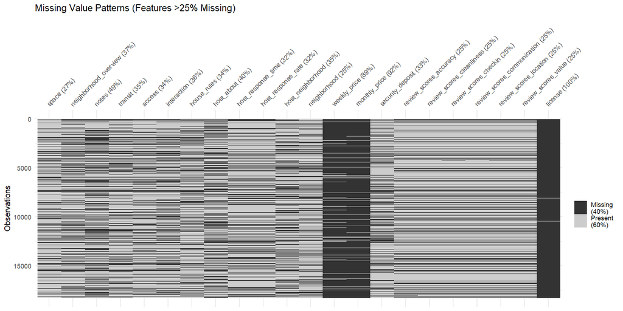

```r
unclean_airbnb_df = read.csv("airbnb_data.csv")
airbnb_df <- read.csv("dataset_cleaned_2.csv")
unclean_airbnb_df$price_tier <- as.factor(unclean_airbnb_df$price_tier)
high_missing <- unclean_airbnb_df %>%
  summarise(across(everything(), ~mean(is.na(.)))) %>%
  pivot_longer(cols = everything(),
               names_to = "feature",
               values_to = "missing_pct") %>%
  filter(missing_pct > 0.25) %>%
  pull(feature)

# Plot vis_miss only for those features
vis_miss(unclean_airbnb_df[high_missing]) +
  labs(title = "Missing Value Patterns (Features >25% Missing)") +
  theme(legend.position = "right")
```

- This visualization shows the large numbers of features that have more than 25% of values missing, this implies that more than 25% of the information related to that feature is lost and cannot be easily imputed with other values such as mean/median or mode. This suggests that these features should either be removed or remove the rows that miss values in these attributes. But as the records may hold valuable information about other features in the dataset, it is preferrable that we delete the attributes instead as due to the number of missing values implies that they may not contribute greatly to the classification model. - In the cleaned dataset is we try to completely remove/replace missing values by being imputed by the median of the numerical features and the mode for the nominal/ordinal features. Here, we also observe that the columns that were greatly missing values as shown in the previous graph has been dropped due to the assumption that they will not provide any useful information that is not artifically added by us if we simply imputed the data.

## 3.3 Feature Engineering

```r
# REMOVING LEAKAGE FEATURES

leakage_features <- c(
  # Direct price variables - CRITICAL LEAKAGE
  "price_label", "weekly_price", "monthly_price",

  # Post-listing review metrics - don't exist for new listings
  "number_of_reviews", "first_review", "last_review",
  "reviews_per_month",
  "review_scores_rating", "review_scores_accuracy",
  "review_scores_cleanliness", "review_scores_checkin",
  "review_scores_communication", "review_scores_location",
  "review_scores_value",  # Especially this - compares value to price!

  # Availability/booking outcomes - results of pricing strategy
   "calendar_last_scraped",

  # Administrative/metadata - not predictive
  "id", "listing_url", "scrape_id", "last_scraped",
  "host_id", "host_url", "picture_url",
  "host_thumbnail_url", "host_picture_url",
  "name", "neighborhood_overview", "notes",
  "transit", "access", "interaction", "house_rules",

  # Geographic coordinates - prevent overfitting to exact locations
  "latitude", "longitude", "smart_location",
  "street", "city", "state", "zipcode", "country", "country_code",

  # License info - mostly missing and not predictive
  "license", "requires_license"
)

# Remove leakage features
airbnb_clean <- airbnb_clean %>%
  select(-any_of(leakage_features))

#############################################################################
# Check cardinality of character variables
high_cardinality <- airbnb_clean %>%
  select(where(is.character)) %>%
  summarise(across(everything(), n_distinct)) %>%
  pivot_longer(everything(), names_to = "variable", values_to = "n_unique") %>%
  filter(n_unique > 50)
high_cardinality


# STEP 3: PARSE AMENITIES INTO BINARY FEATURES
# ==========================================================================

# Function to safely detect amenities
detect_amenity <- function(amenities_col, amenity_name) {
  stringr::str_detect(amenities_col, stringr::fixed(amenity_name))
}

# Define key amenities that differentiate price tiers
# Focus is on structural/permanent features, not operational decisions
airbnb_clean <- airbnb_clean %>%
  mutate(
    # Essential amenities (common across tiers)
    has_wifi = detect_amenity(amenities, "Wifi"),
    has_kitchen = detect_amenity(amenities, "Kitchen"),
    has_tv = detect_amenity(amenities, "TV"),
    has_heating = detect_amenity(amenities, "Heating"),
    has_air_conditioning = detect_amenity(amenities, "Air conditioning"),
    has_washer = detect_amenity(amenities, "Washer"),
    has_dryer = detect_amenity(amenities, "Dryer"),

    # Premium amenities (differentiate higher tiers)
    has_pool = detect_amenity(amenities, "Pool"),
    has_hot_tub = detect_amenity(amenities, "Hot tub"),
    has_gym = detect_amenity(amenities, "Gym"),
    has_elevator = detect_amenity(amenities, "Elevator"),
    has_indoor_fireplace = detect_amenity(amenities, "Indoor fireplace"),
    has_waterfront = detect_amenity(amenities, "Waterfront"),
    has_beachfront = detect_amenity(amenities, "Beachfront"),

    # Parking (important in Melbourne)
    has_free_parking = detect_amenity(amenities, "Free parking on premises"),
    has_street_parking = detect_amenity(amenities, "Free street parking"),
    has_paid_parking = detect_amenity(amenities, "Paid parking off premises"),

    # Work amenities (increasingly important)
    has_workspace = detect_amenity(amenities, "Laptop friendly workspace"),
    has_dedicated_workspace = detect_amenity(amenities, "Dedicated workspace"),

    # Safety features (might indicate professional hosts)
    has_smoke_detector = detect_amenity(amenities, "Smoke detector"),
    has_carbon_monoxide = detect_amenity(amenities, "Carbon monoxide detector"),
    has_fire_extinguisher = detect_amenity(amenities, "Fire extinguisher"),
    has_first_aid = detect_amenity(amenities, "First aid kit"),

    # Accessibility
    has_wheelchair_access = detect_amenity(amenities, "Wheelchair accessible"),
    has_step_free = detect_amenity(amenities, "Step-free access"),

    # Family amenities
    has_family_friendly = detect_amenity(amenities, "Family/kid friendly"),
    has_high_chair = detect_amenity(amenities, "High chair"),
    has_crib = detect_amenity(amenities, "Crib"),

    # Guest convenience
    has_self_checkin = detect_amenity(amenities, "Self check-in"),
    has_lockbox = detect_amenity(amenities, "Lockbox"),

    # Policies (use cautiously - might be strategic responses to market)
    allows_pets = detect_amenity(amenities, "Pets allowed"),
    allows_smoking = detect_amenity(amenities, "Smoking allowed"),

    # Aggregated counts
    total_amenities = str_count(amenities, '","') + 1,

    premium_amenity_count =
      has_pool + has_hot_tub + has_gym + has_elevator +
      has_indoor_fireplace + has_waterfront + has_beachfront,

    essential_amenity_count =
      has_wifi + has_kitchen + has_air_conditioning +
      has_heating + has_washer + has_tv,

    safety_amenity_count =
      has_smoke_detector + has_carbon_monoxide +
      has_fire_extinguisher + has_first_aid,

    # Derived features
    has_any_parking = has_free_parking | has_street_parking | has_paid_parking,
    is_remote_work_ready = has_workspace & has_wifi,
    premium_ratio = premium_amenity_count / (total_amenities + 1)
  ) %>%
  select(-amenities)  # Remove original amenities string


# ============================================================================
# STEP 4: HANDLE HOST VERIFICATION COLUMNS
# ============================================================================

# Instead of 18+ individual verification columns, created summary metrics
verification_cols <- grep("host_verifications_", names(airbnb_clean), value = TRUE)

if (length(verification_cols) > 0) {
  airbnb_clean <- airbnb_clean %>%
    mutate(
      verification_count = rowSums(
        select(., all_of(verification_cols)) == "True" |
        select(., all_of(verification_cols)) == TRUE,
        na.rm = TRUE
      ),
      has_government_id = if_else(
        host_verifications_government_id %in% c("True", TRUE), TRUE, FALSE
      ),
      has_jumio_verification = if_else(
        host_verifications_jumio %in% c("True", TRUE), TRUE, FALSE
      )
    ) %>%
    select(-all_of(verification_cols))
}


# ============================================================================
# STEP 5: FEATURE ENGINEERING (PRE-SPLIT)
# ============================================================================

airbnb_clean <- airbnb_clean %>%
  mutate(
    # Host tenure (experience indicator)
    host_since_date = as.Date(host_since, format = "%m/%d/%Y"),
    scrape_date = as.Date("2018-12-07"),  # Based on data
    host_tenure_days = as.numeric(scrape_date - host_since_date),
    host_tenure_years = host_tenure_days / 365.25,

    # Property capacity metrics
    guests_per_bedroom = accommodates / (bedrooms + 0.1),
    beds_per_bedroom = beds / (bedrooms + 0.1),
    bathrooms_per_guest = bathrooms / (accommodates + 0.1),

    is_flexible_stay = minimum_nights <= 2,
    accepts_long_stays = maximum_nights >= 365,

    # Host activity level (might indicate professionalism)
    is_multi_listing_host = calculated_host_listings_count > 1,
    host_listing_intensity = log1p(calculated_host_listings_count),

    # Response indicators (if host_response_rate exists)
    is_responsive_host = if_else(!is.na(host_response_rate) & host_response_rate >= 90,
                                  TRUE, FALSE, missing = FALSE)
  ) %>%
  select(-host_since_date, -scrape_date, -host_tenure_days, -host_since)


# ============================================================================
# STEP 6: CONVERT CATEGORICAL VARIABLES TO FACTORS
# ============================================================================

# Convert character variables to factors for Random Forest
categorical_vars <- c(
  "property_type", "room_type", "bed_type",
  "neighborhood", "cancellation_policy",
  "host_response_time"
)

airbnb_clean <- airbnb_clean %>%
  mutate(across(any_of(categorical_vars), as.factor))

# Handle high-cardinality categoricals
# If property_type has too many levels, group rare ones
if ("property_type" %in% names(airbnb_clean)) {
  property_freq <- airbnb_clean %>%
    count(property_type) %>%
    mutate(prop = n / sum(n))

  # Keep types that appear in >2% of listings, group others as "Other"
  common_types <- property_freq %>%
    filter(prop > 0.02) %>%
    pull(property_type)

  airbnb_clean <- airbnb_clean %>%
    mutate(property_type = if_else(property_type %in% common_types,
                                    as.character(property_type),
                                    "Other"),
           property_type = factor(property_type))
}


# ============================================================================
# STEP 7: REMOVE NEAR-ZERO VARIANCE PREDICTORS
# ============================================================================

# Identify features with no variance (all same value)
nzv_check <- nearZeroVar(airbnb_clean %>% select(-price_tier),
                         saveMetrics = TRUE)
nzv_remove <- rownames(nzv_check[nzv_check$nzv == TRUE, ])

if (length(nzv_remove) > 0) {
  #cat("Removing", length(nzv_remove), "near-zero variance features:\n")
  #cat(paste(nzv_remove, collapse = ", "), "\n")

  airbnb_clean2 <- airbnb_clean %>%
    select(-any_of(nzv_remove))
}


# ============================================================================
# STEP 8: HANDLE EXTREME OUTLIERS
# ============================================================================

airbnb_clean2 <- airbnb_clean2 %>%
  mutate(
    # Cap unrealistic values
    minimum_nights = if_else(minimum_nights > 365, 365, minimum_nights),
    maximum_nights = if_else(maximum_nights > 365*10, 365*10, maximum_nights),

    # Cap extreme host listing counts (likely data errors or hotel chains)
    calculated_host_listings_count = if_else(
      calculated_host_listings_count > 50, 50, calculated_host_listings_count
    ),

    # Cap accommodates (listings claiming 16+ guests are unusual)
    accommodates = if_else(accommodates > 12, 12, accommodates)
  )

airbnb_clean2$neighborhood <- NULL
airbnb_clean3 <- feature_engineering(airbnb_clean2)
```

One of the feature selection and dimensionality reduction method we used is near-zero variance removal. In terms of handling outliers we used winsorization (capping) rather than removal to preserve all observations while limiting outlier influence.

#### 3.3.0.1 Split the data

```r
# ============================================================================
# STEP 10: STRATIFIED TRAIN/TEST SPLIT
# ===========================================================================

set.seed(42)  # For reproducibility
data_split <- initial_split(airbnb_clean3, prop = 0.75, strata = price_tier)

train_raw <- training(data_split)
test_raw <- testing(data_split)

cat("Training set:", nrow(train_raw), "rows\n")
cat("Test set:", nrow(test_raw), "rows\n")

# Verify stratification worked
cat("\nTraining set distribution:\n")
print(prop.table(table(train_raw$price_tier)))

cat("\nTest set distribution:\n")
print(prop.table(table(test_raw$price_tier)))

# 3) Compute imputers from *training* data only
train_medians <- compute_train_medians(train_raw)
train_modes   <- compute_train_modes(train_raw)

# 4) Apply imputation to both sets using training stats
df_train <- imputation(train_raw, train_medians, train_modes)
df_test  <- imputation(test_raw,  train_medians, train_modes)

#print(colSums(is.na(df_train)))
#print(sapply(df_train, class))
#print(colnames(df_train)[colSums(is.na(df_train)) > 0])

#write.csv(df_train, file = "df_train.csv", row.names = FALSE)
#write.csv(df_test, file = "df_test.csv", row.names = FALSE)


# save cleaned dataset for EDA
#airbnb_data <- clean(airbnb_data)
#all_medians <- compute_train_medians(airbnb_data)
#all_modes   <- compute_train_modes(airbnb_data)
#airbnb_data <- imputation(airbnb_data, all_medians, all_modes)
#airbnb_data <- feature_engineering(airbnb_data)
#write.csv(airbnb_data, file = "dataset_cleaned_2.csv", row.names = FALSE)
```

To ensure a robust evaluation, the data was then stratified and split into training (75%) and testing (25%) sets before any imputation.

All imputation values calculated from training data only, then applied to both training and test sets.We used median imputation because median is robust to outliers which is appropriate for skewed distributions and for categorical variables we used mode (most frequent category). Finally, we engineered new features by one-hot encoding of all categorical variables resulting in a clean and feature-rich dataset ready for the modeling phase.

# 4 Data Exploration and Visualization

## 4.1 Loading Datasets

- Here we loaded both the cleaned and uncleaned datasets to visually understand the different results and challenges the uncleaned dataset has posed in regards to solving the classification problem.

```r
library(tidyr)
library(tidyverse)
library(dplyr)

unclean_airbnb_df = read.csv("airbnb_data.csv")
airbnb_df <- read.csv("dataset_cleaned_2.csv")
```

## 4.2 Data Analysis

### 4.2.1 Data visualization

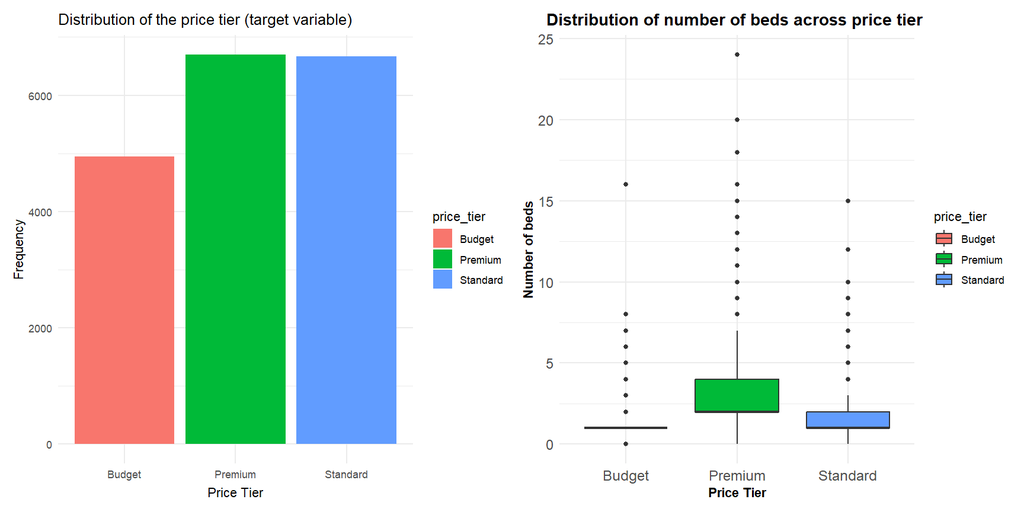

```r
library(ggplot2)
library(visdat)
library(patchwork)
library(ggthemes)

unclean_airbnb_df$price_tier <- as.factor(unclean_airbnb_df$price_tier)

p1 <- ggplot(airbnb_df, aes(x = price_tier, fill=price_tier)) +
  geom_bar()+
  labs(title="Distribution of the price tier (target variable)", x="Price Tier", y="Frequency") + theme_minimal()


p2 <- ggplot(airbnb_df, aes(x = price_tier, y = beds, fill = price_tier)) + geom_boxplot()+
  labs(title="Distribution of number of beds across price tier ", x="Price Tier", y="Number of beds") + theme_minimal() + theme(
    plot.title = element_text(face = "bold", size = 14, hjust = 0.5),
    axis.title = element_text(face = "bold"),
    axis.text = element_text(size = 12)
  )

p1 + p2
```

- Here we see that the target class of our dataset are relatively balanced showing that there is an equal distribution of houses available to rent in the Airbnb Melbourne site. Another very informative plot is the boxplot that can be seen it shows the distribution of number of beds across the type of houses which shows that premium houses seem to have a higher median number of beds as compared to the other 2 types.

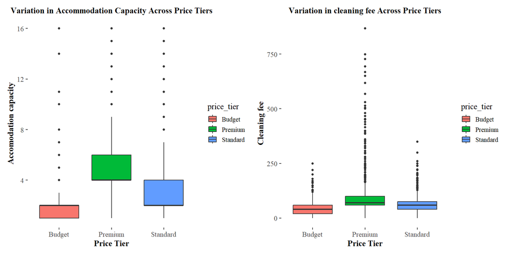

```r
p3 <- ggplot(airbnb_df, aes(x = price_tier, y = accommodates, fill = price_tier)) + geom_boxplot()+
  labs(title="Variation in Accommodation Capacity Across Price Tiers", x="Price Tier", y="Accomodation capacity") + theme_tufte(base_size = 14, base_family = "serif") + theme(
    plot.title = element_text(face = "bold", size = 14, hjust = 0.5),
    axis.title = element_text(face = "bold"),
    axis.text = element_text(size = 12)
  )


p4 <- ggplot(airbnb_df, aes(x = price_tier, y = cleaning_fee, fill = price_tier)) + geom_boxplot()+
  labs(title="Variation in cleaning fee Across Price Tiers", x="Price Tier", y="Cleaning fee") + theme_tufte(base_size = 14, base_family = "serif") + theme(
    plot.title = element_text(face = "bold", size = 14, hjust = 0.5),
    axis.title = element_text(face = "bold"),
    axis.text = element_text(size = 12)
  )


p3 + p4
```

## 4.3 Analysis of Correlation between features

#### 4.3.0.1 Uncleaned Dataset

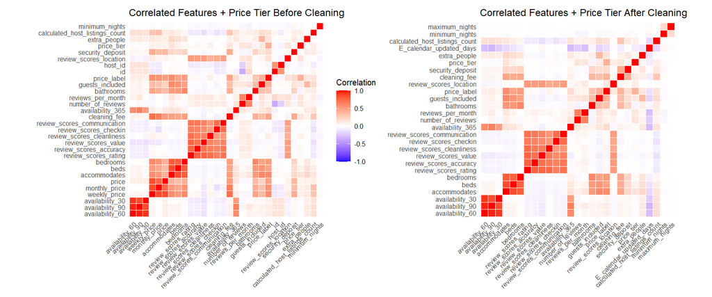

```r
library(corrplot)
library(ggplot2)
library(patchwork)
library(reshape2)

og_price_tier_unclean <- unclean_airbnb_df$price_tier
og_price_tier_clean <- airbnb_df$price_tier
unclean_airbnb_df$price_tier <- as.numeric(as.factor(unclean_airbnb_df$price_tier)) - 1
airbnb_df$price_tier <- as.numeric(as.factor(airbnb_df$price_tier)) - 1

num_features <- unclean_airbnb_df[sapply(unclean_airbnb_df, is.numeric)]
num_features <- num_features[, apply(num_features, 2, function(x) {
  var(x, na.rm = TRUE) > 0
})]
corr_mat1 <- cor(num_features, use="pairwise.complete.obs")
corr_mat1_mod <- abs(corr_mat1)
diag(corr_mat1_mod) <- 0
top_features <- names(sort(apply(corr_mat1_mod, 2, max), decreasing = TRUE))[1:30]
top_features <- c(top_features, "price_tier")
top_corr_mat1 <- corr_mat1[top_features, top_features]
corr_df_top1 <- melt(top_corr_mat1)

num_features1 <- airbnb_df[sapply(airbnb_df, is.numeric)]
corr_mat2 <- cor(num_features1, use="pairwise.complete.obs")
corr_mat2_mod <- abs(corr_mat2)
diag(corr_mat2_mod) <- 0
top_features <- names(sort(apply(corr_mat2_mod, 2, max), decreasing = TRUE))[1:27]
top_features <- c(top_features, "price_tier")
top_corr_mat2 <- corr_mat2[top_features, top_features]
corr_df_top2 <- melt(top_corr_mat2)

# Plot 1 - Before Cleaning
p1 <- ggplot(corr_df_top1, aes(Var1, Var2, fill = value)) +
  geom_tile(color = "white") +
  scale_fill_gradient2(low = "blue", mid = "white", high = "red",
                       midpoint = 0, limit = c(-1, 1), name = "Correlation") +
  theme_minimal(base_size = 10) +  # base_size adjusts all text
  theme(
    axis.text.x = element_text(angle = 45, vjust = 1, hjust = 1, size = 8),
    axis.text.y = element_text(size = 8),
    axis.ticks = element_blank()
  ) +
  labs(title = "Correlated Features + Price Tier Before Cleaning", x = NULL, y = NULL) + coord_fixed()

# Plot 2 - After Cleaning
p2 <- ggplot(corr_df_top2, aes(Var1, Var2, fill = value)) +
  geom_tile(color = "white") +
  scale_fill_gradient2(low = "blue", mid = "white", high = "red",
                       midpoint = 0, limit = c(-1, 1), guide = "none") +
  theme_minimal(base_size = 10) +
  theme(
    axis.text.x = element_text(angle = 45, vjust = 1, hjust = 1, size = 8),
    axis.text.y = element_text(size = 8),
    axis.ticks = element_blank()
  ) +
  labs(title = "Correlated Features + Price Tier After Cleaning", x = NULL, y = NULL) + coord_fixed()

# Combine side by side
p1 + p2
```

```r
airbnb_df$price_tier <- factor(airbnb_df$price_tier,
                              levels = c(0, 1, 2),
                              labels = c("Budget", "Standard", "Premium"))
```

### 4.3.1 PCA Analysis to understand Class Separation

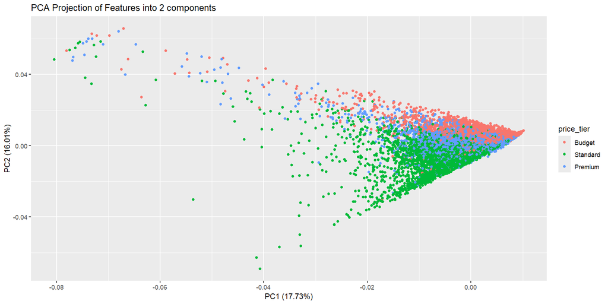

```r
library(ggfortify)
pca <- prcomp(num_features1, scale=TRUE)
autoplot(pca, data=airbnb_df, colour="price_tier") +
  ggtitle("PCA Projection of Features into 2 components")
```

- This PCA analysis highlights the difficulty in class separation. This visualization shows us clearly how all the three tier housing are extremely close to each other even while considering only 2 principal components, so simple linear algorithms like Logistic Regression and LDA may not be the most appropriate models to separate the classes from each other. This added complexity of the dataset further compels the dataset to undergo more cleaning other than just handling missing data such as outlier analysis, dimensionality reduction or handling missing data again using other machine learning models/bootstrap.

# 5 Modeling

This report presents a comprehensive comparison of five machine learning approaches for classifying Melbourne Airbnb listings into price tiers (Budget, Standard, Premium):

1. **Random Forest** - Ensemble of decision trees
2. **XGBoost** - Gradient boosted trees
3. **Multinomial Logistic Regression with Elastic Net** - Regularized linear model
4. **k-Nearest Neighbors** - Instance-based learning
5. **Support Vector Machine with PCA** - Kernel-based with dimensionality reduction. And we will use **Accuracy**, **F1-score**, **sensitivity**, **confusion matrix** and **specificity** as some of our evaluation metrics together with **hyperaparameter tuning** and **cross validation** to get the best combination of parameters for the models.

**Dataset:** 13738 training observations, 4578 test observations, 124 features

## 5.1 Support Vector Machine

Nested Cross-Validation to find the best hyperparameters for support vector machine model - Having the outer folds of the nested cross validation for getting the mean accuracy of the model - The inner cross validation will be used to find the best hyperparameter (sigma and cost(C)) for the SVM model to perform at its best - The k-Folds architecture will be using a 5-fold CV architecture for the outer cross validation and a 3-fold CV architecture for the hyperparameter tuning of the SVM model

```r
# If tuning results exist, skip model training and load directly
if (file.exists("svm_tune_res.rds")) {
  #cat("✅ Loading saved SVM tuning results...\n")
  svm_results <- readRDS("svm_tune_res.rds")
  final_svm <- svm_results$final_model
  tune_results <- svm_results$tune_results
  best.params <- svm_results$best_params
} else {
  #cat("⚙️ Running SVM hyperparameter tuning (first run — may take several minutes)...\n")

  outer_folds <- createFolds(process.train$price_tier, k = 5, list = TRUE, returnTrain = TRUE)
  tune_grid <- expand.grid(
    C = c(0.1, 1, 10),
    sigma = c(0.001, 0.01, 0.1)
  )

  for (i in seq_along(outer_folds)) {
    train_idx <- outer_folds[[i]]
    train_data <- process.train[train_idx, ]
    test_data  <- process.train[-train_idx, ]

    train_control <- trainControl(
      method = "cv",
      number = 3,
      allowParallel = TRUE
    )

    svm_tune <- train(
      price_tier ~ .,
      data = train_data,
      method = "svmRadial",
      metric = "Accuracy",
      tuneGrid = tune_grid,
      trControl = train_control,
      preProcess = c("center", "scale"),
      tuneLength = 5
    )

    preds <- predict(svm_tune, newdata = test_data)
    cat("Fold", i, "completed.\n")
  }

  # Stop parallel backend
  stopCluster(cl)
  registerDoSEQ()

  tune_results <- svm_tune$results
  best.params <- svm_tune$bestTune

  # Fit final SVM with best params
  final_svm <- svm(
    price_tier ~ .,
    data = process.train,
    kernel = "radial",
    cost = best.params$C,
    gamma = best.params$sigma
  )

  svm_results <- list(
    tune_results = tune_results,
    best_params = best.params,
    final_model = final_svm
  )

  saveRDS(svm_results, file = "svm_tune_res.rds")
  #cat("💾 SVM tuning complete and saved to svm_tune_res.rds\n")
}
```

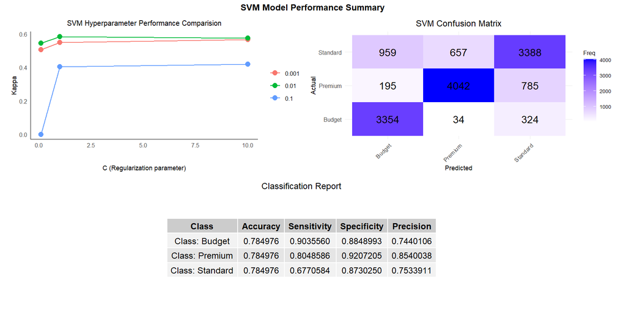

```r
svm_results <- readRDS("svm_tune_res.rds")
final_svm <- svm_results$final_model
tune_results <- svm_results$tune_results
preds <- predict(final_svm, newdata = process.test)
plt1 <- ggplot(tune_results, aes(x = C, y = Kappa, color = factor(sigma))) +
  geom_line() +
  geom_point(size = 3) +
  theme_minimal() +
  labs(
    title = "SVM Hyperparameter Performance Comparision",
    x = "C (Regularization parameter)",
    y = "Kappa",
    color = "Sigma"
  )+
  theme_minimal(base_size = 10) +  # Reduced base size for grid layout
  theme(
    plot.title = element_text(hjust = 0.5, size = 10),
    legend.title = element_blank(),
    legend.text = element_text(size = 8),
    axis.title = element_text(size = 9),
    axis.text = element_text(size = 8),
    axis.line = element_line(color = "black"),
    panel.grid = element_blank()
  )

cm <- confusionMatrix(preds, process.test$price_tier)

cm_df <- as.data.frame(cm$table)

# Build results table
results_table <- data.frame(
  Class        = rownames(cm$byClass),
  Accuracy     = cm$overall["Accuracy"],
  Sensitivity  = cm$byClass[,"Sensitivity"],
  Specificity  = cm$byClass[,"Specificity"],
  Precision    = cm$byClass[,"Pos Pred Value"]
)

table <- ggplot() +
  annotation_custom(
    grob = tableGrob(
      results_table,
      rows = NULL
    )
  ) +
  theme_void() +
  labs(
    title = "Classification Report"
  ) +
  theme(
    plot.title = element_text(
      size = 12,
      hjust = 0.5,
      margin = margin(b = 5)
    ),
    plot.subtitle = element_text(
      size = 11,
      hjust = 0.5,
      margin = margin(b = 10)
    ),
    plot.margin = margin(10, 10, 10, 10)
  )


plt2 <- ggplot(cm_df, aes(Prediction, Reference, fill = Freq)) +
  geom_tile() +
  geom_text(aes(label = Freq), color = "black", size = 5) +
  scale_fill_gradient(low = "white", high = "blue") +
  labs(title = "SVM Confusion Matrix",
       x = "Predicted",
       y = "Actual") +
  theme_minimal(base_size=10) +
  theme(
    plot.title = element_text(hjust = 0.5, size = 12),
    axis.title = element_text(size = 9),
    axis.text = element_text(size = 8),
    axis.text.x = element_text(angle = 45, hjust = 1),
    legend.title = element_text(size = 8),
    legend.text = element_text(size = 7)
  )

(plt1 | plt2) / (table) +
  plot_annotation(
    title = "SVM Model Performance Summary",
    theme = theme(
      plot.title = element_text(size = 12, face = "bold", hjust = 0.5)
    )
  )
```

## 5.2 Random Forest model

This analysis implements a **Random Forest classifier** to predict Airbnb price tiers (Budget, Standard, Premium) in Melbourne. Random Forest is an ensemble method that builds multiple decision trees and aggregates their predictions, providing robust performance and natural resistance to overfitting.

### 5.2.1 Cross-Validation Strategy

- Used a **5-fold stratified cross-validation** to maintain class balance and random seed (123) for reproducibility We also applied preprocessing steps for the workflow to be reproducible:
1. **Logical to numeric conversion**: TRUE/FALSE → 1/0 (required for ranger). 2. **Missing value imputation**: Median for numeric, mode for categorical. 3. **Zero-variance removal**: Eliminate uninformative constant features. 4. **Correlation filtering**: Remove highly correlated features (r > 0.9). 5. **Feature normalization**: Standardize numeric predictors for consistent importance metrics. 6. **Rare category grouping**: Combine categories with <1% frequency

### 5.2.2 Model Specification

```r
# Cross validation
set.seed(123)
cv_folds <- vfold_cv(df_train, v = 5, strata = price_tier)

# preprocess the data
rf_recipe <- recipe(price_tier ~ ., data = df_train) %>%
  step_rm(matches("^id$|^ID$"), skip = TRUE) %>%
  step_mutate(across(where(is.logical), as.numeric)) %>%
  step_impute_median(all_numeric_predictors()) %>%
  step_impute_mode(all_nominal_predictors()) %>%
  step_zv(all_predictors()) %>%
  step_corr(all_numeric_predictors(), threshold = 0.9) %>%
  step_normalize(all_numeric_predictors()) %>%
  step_other(all_nominal_predictors(), threshold = 0.01, other = "other_combined") %>%
  step_dummy(all_nominal_predictors())

# define your model
rf_spec <- rand_forest(
  mtry = tune(),
  trees = tune(),
  min_n = tune()
) %>%
  set_engine(
    "ranger",
    importance = "impurity",
    seed = 123,
    num.threads = 1
  ) %>%
  set_mode("classification")

# Create a workflow
rf_workflow <- workflow() %>%
  add_recipe(rf_recipe) %>%
  add_model(rf_spec)

# define the metrics
multiclass_metrics <- yardstick::metric_set(
  yardstick::accuracy,
  yardstick::roc_auc,
  yardstick::mn_log_loss,
  yardstick::sens,
  yardstick::spec,
  yardstick::precision,
  yardstick::f_meas
)
```

```r
# Check if tuning results already exist
if (file.exists("rf_tune_res.rds")) {
  #cat("✅ Loading saved tuning results...\n")
  rf_list <- readRDS("rf_tune_res.rds")
  rf_tune_results <- rf_list$tune_results
  rf_workflow <- rf_list$rf_workflow
} else {
  cat("⚙️ Running hyperparameter tuning (first time, may take a while)...\n")

  rf_grid <- grid_space_filling(
    parameters(
      mtry(range = c(5, 20)),
      trees(range = c(1000, 2000)),
      min_n(range = c(1, 9))
    ),
    size = 5,
    original = "lhs"
  )

  tune_control <- control_grid(
    save_pred = TRUE,
    save_workflow = FALSE,
    verbose = FALSE,
    allow_par = TRUE,
    parallel_over = "everything"
  )

  start_time <- Sys.time()
  set.seed(456)

  rf_tune_results <- tune_grid(
    rf_workflow,
    resamples = cv_folds,
    grid = rf_grid,
    metrics = multiclass_metrics,
    control = tune_control
  )

  rf_list <- list(
    tune_results = rf_tune_results,
    rf_workflow = rf_workflow
  )

  saveRDS(rf_list, file = "rf_tune_res.rds")
  end_time <- Sys.time()
  tuning_duration <- difftime(end_time, start_time, units = "mins")
  #cat("💾 Tuning complete and saved. Duration:", round(tuning_duration, 2), "mins\n")
}
```

### 5.2.3 Hyperparameter Tuning Visualization

```r
final_rf_workflow <- finalize_workflow(rf_workflow, best_params)
final_rf_fit <- fit(final_rf_workflow, data = df_train)
final_rf_model <- extract_fit_parsnip(final_rf_fit)

test_predictions <- predict(final_rf_fit, df_test) %>%
  bind_cols(predict(final_rf_fit, df_test, type = "prob")) %>%
  bind_cols(df_test %>% select(price_tier))

# Calculate all metrics
test_accuracy <- yardstick::accuracy(test_predictions, truth = price_tier, estimate = .pred_class)
test_sensitivity <- yardstick::sensitivity(test_predictions, truth = price_tier, estimate = .pred_class, estimator = "macro")
test_specificity <- yardstick::specificity(test_predictions, truth = price_tier, estimate = .pred_class, estimator = "macro")
test_precision <- yardstick::precision(test_predictions, truth = price_tier, estimate = .pred_class, estimator = "macro")
test_f1 <- yardstick::f_meas(test_predictions, truth = price_tier, estimate = .pred_class, estimator = "macro")

prob_cols <- names(test_predictions)[stringr::str_detect(names(test_predictions), "^\\.pred_")]
prob_cols <- prob_cols[prob_cols != ".pred_class"]
test_roc_auc <- yardstick::roc_auc(test_predictions, truth = price_tier, all_of(prob_cols), estimator = "hand_till")

test_logloss <- yardstick::mn_log_loss(test_predictions, truth = price_tier, all_of(prob_cols))
```

### 5.2.4 ROC Curves and parameter tuning visualization

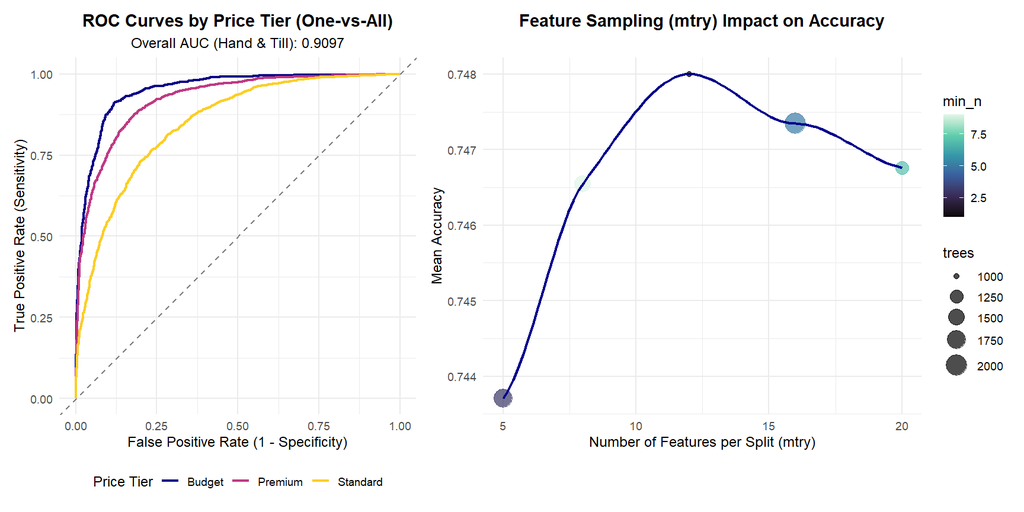

ROC curves for each price tier using one-vs-all strategy. Curves closer to top-left indicate better discrimination.

```r
roc_data <- test_predictions %>%
  yardstick::roc_curve(truth = price_tier, all_of(prob_cols))

# autoplot(roc_data) +
#   labs(
#     title = "ROC Curves by Price Tier (One-vs-All)",
#     subtitle = paste0("Overall AUC (Hand & Till): ", round(test_roc_auc$.estimate, 4))
#   ) +
#   theme_minimal(base_size = 12) +
#   theme(
#     plot.title = element_text(hjust = 0.5, face = "bold"),
#     plot.subtitle = element_text(hjust = 0.5),
#     legend.position = "bottom"
#   )

g3 <- roc_data %>%
  ggplot(aes(x = 1 - specificity, y = sensitivity, color = .level)) +
  geom_path(linewidth = 1) +
  geom_abline(lty = 2, color = "gray50") +
  coord_equal() +
  scale_color_viridis_d(option = "plasma", end = 0.9) +
  labs(
    title = "ROC Curves by Price Tier (One-vs-All)",
    subtitle = paste0("Overall AUC (Hand & Till): ", round(test_roc_auc$.estimate, 4)),
    x = "False Positive Rate (1 - Specificity)",
    y = "True Positive Rate (Sensitivity)",
    color = "Price Tier"
  ) +
  theme_minimal(base_size = 12) +
  theme(
    plot.title = element_text(hjust = 0.5, face = "bold"),
    plot.subtitle = element_text(hjust = 0.5),
    legend.position = "bottom"
  )

g3+g1
```

```r
comparison <- tibble(
  Metric = c("ROC AUC", "Accuracy", "F1 Score"),
  `Cross-Validation` = c(
    show_best(rf_tune_results, metric = "roc_auc", n = 1)$mean,
    show_best(rf_tune_results, metric = "accuracy", n = 1)$mean,
    show_best(rf_tune_results, metric = "f_meas", n = 1)$mean
  ),
  `Test Set` = c(
    test_roc_auc$.estimate,
    test_accuracy$.estimate,
    test_f1$.estimate
  )
) %>%
  mutate(
    Difference = `Test Set` - `Cross-Validation`,
    `% Change` = round((Difference / `Cross-Validation`) * 100, 2),
    across(c(`Cross-Validation`, `Test Set`), ~round(., 4))
  )

# knitr::kable(
#  comparison,
#  caption = "Cross-Validation vs Test Set Performance Comparison")

g4 <- gridExtra::tableGrob(
  comparison,
  rows = NULL,
  theme = gridExtra::ttheme_minimal(
    core = list(fg_params = list(hjust = 0, x = 0.1)),
    colhead = list(fg_params = list(fontface = "bold"))
  )
)

# Add title to the table
g4 <- gridExtra::arrangeGrob(
  g4,
  top = grid::textGrob(
    "Cross-Validation vs Test Set Performance",
    gp = grid::gpar(fontsize = 12, fontface = "bold")
  )
)
```

#### 5.2.4.1 Most Important Feature analysis and model generalization

[figure not shown]

Variable importance based on mean decrease in Gini impurity. Higher values indicate more influential features.

```r
g2 <- importance_scores %>%
  slice_max(order_by = Importance, n = 20) %>%
  ggplot(aes(x = Importance, y = reorder(Variable, Importance))) +
  geom_col(fill = "steelblue", alpha = 0.8) +
  geom_text(aes(label = round(Importance, 1)), hjust = -0.1, size = 3) +
  labs(
    title = "Top 20 Most Important Features",
    subtitle = "Random Forest - Gini Impurity Importance",
    x = "Importance Score",
    y = NULL
  ) +
  theme_minimal(base_size = 12) +
  theme(
    plot.title = element_text(hjust = 0.5, face = "bold"),
    plot.subtitle = element_text(hjust = 0.5),
    panel.grid.major.y = element_blank()
  ) +
  xlim(0, max(importance_scores$Importance[1:20]) * 1.1)


g2+wrap_elements(g4)
```

### 5.2.5 Model Performance Summary

The Random Forest classifier achieved: - **76.3% overall accuracy** on the test set - **0.91 ROC AUC** indicating excellent discrimination ability - **0.765 F1 score** demonstrating balanced precision and recall - **0.6% difference** between CV and test performance (strong generalization)

## 5.3 K Nearest Neighbors

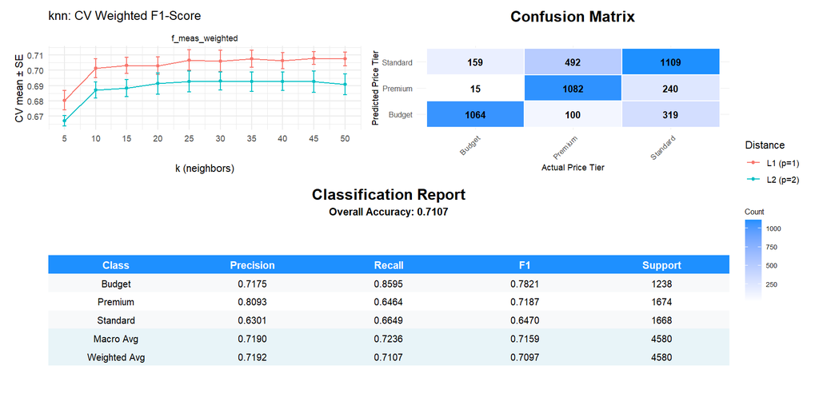

```r
library(tidymodels)
library(yardstick)
library(gridExtra)
library(patchwork)

# load preprocessed data
train = read.csv('train.csv')
test = read.csv('test.csv')

# convert target column to factor
train$price_tier <- as.factor(train$price_tier)
test$price_tier <- as.factor(test$price_tier)

# standardization: important for knn as knn is sensitive to scale
rec <- recipe(price_tier ~ ., data = train) %>%
  step_normalize(all_numeric_predictors())


# ================================================
#               HYPERPARAMETER TUNING
# ================================================

# Define model and workflow
knn_def <- nearest_neighbor(
  mode = 'classification',
  neighbors  = tune(),
  dist_power  = tune(),
  weight_func = "rectangular" # unweighted -> standard kNN
) %>%
  set_engine("kknn")

knn_wf <- workflow() %>%
  add_model(knn_def) %>%
  add_recipe(rec)

# Cross-validation folds
set.seed(5003)
cv_folds <- vfold_cv(train, v = 5, strata = price_tier)

# Define weighted metrics for multiclass classification
f_meas_weighted <- metric_tweak(
  .name = "f_meas_weighted",
  .fn   = yardstick::f_meas,
  estimator = "macro_weighted"
)

precision_weighted <- metric_tweak(
  .name = "precision_weighted",
  .fn   = yardstick::precision,
  estimator = "macro_weighted"
)

recall_weighted <- metric_tweak(
  .name = "recall_weighted",
  .fn   = yardstick::recall,
  estimator = "macro_weighted"
)

multiclass_metrics <- metric_set(
  yardstick::accuracy,
  yardstick::sens,
  yardstick::spec,
  yardstick::precision,
  yardstick::f_meas,
  f_meas_weighted,
  precision_weighted,
  recall_weighted
)

# Define parameter grid
param_grid <- tidyr::crossing(
  neighbors  = seq(5, 50, 5),
  dist_power = c(1, 2)
)

ctrl <- control_grid(save_pred = TRUE, verbose = TRUE)

# ------------------------------------------------
#        Load or perform tuning
# ------------------------------------------------

if (file.exists("knn_tune_res.rds")) {
  #cat("✅ Loading saved KNN tuning results...\n")
  knn_tune_res <- readRDS("knn_tune_res.rds")
} else {
  #cat("⚙️ Running KNN hyperparameter tuning (this may take a few minutes)...\n")

  knn_tune_res <- tune_grid(
    knn_wf,
    resamples = cv_folds,
    grid      = param_grid,
    metrics   = multiclass_metrics,
    control   = ctrl
  )

  saveRDS(knn_tune_res, file = "knn_tune_res.rds")
  #cat("💾 Tuning results saved to knn_tune_res.rds\n")
}




# ================================================
#                PLOT TUNING RESULTS
# ================================================

m <- collect_metrics(knn_tune_res)

if ("dist_power" %in% names(m)) {
  m <- m %>%
    mutate(dist_power = factor(dist_power,
                               levels = c(1, 2),
                               labels = c("L1 (p=1)", "L2 (p=2)")))
}

res_plot <- m %>%
  filter(.metric %in% c('f_meas_weighted')) %>%
  ggplot(aes(x = neighbors, y = mean,
             color = if ('dist_power' %in% names(m)) dist_power else NULL)) +
  facet_wrap(~ .metric, scales = 'free_y') +
  geom_line() +
  geom_point() +
  geom_errorbar(aes(ymin = mean - std_err, ymax = mean + std_err), width = 0.6) +
  scale_x_continuous(breaks = sort(unique(m$neighbors))) +
  labs(
    title = 'knn: CV Weighted F1-Score',
    x = 'k (neighbors)',
    y = 'CV mean \u00B1 SE',
    color = 'Distance'
  ) +
  theme_minimal()


# ================================================
#     FINAL MODEL (HIGHEST WEIGHTED F1 SCORE)
# ================================================

if (file.exists("best_knn.rds")) {
  #cat("✅ Loading saved final KNN model...\n")
  best_knn <- readRDS("best_knn.rds")
} else {
  #cat("⚙️ Training final KNN model...\n")
  best_params <- select_best(knn_tune_res, metric = 'f_meas_weighted')
  best_knn_wf <- finalize_workflow(knn_wf, best_params)
  best_knn <- fit(best_knn_wf, data = train)
  saveRDS(best_knn, file = "best_knn.rds")
  #cat("💾 Final KNN model saved to best_knn.rds\n")
}



# ================================================
#     PLOTS TO EVALUATE FINAL MODEL PERFORMANCE
# ================================================

# Check if saved predictions exist
if (file.exists("best_knn_pred.rds")) {
  #message("Loading saved predictions...")
  best_knn_pred <- readRDS("best_knn_pred.rds")
} else {
  #message("Generating predictions and saving results...")
  best_knn_pred <- predict(best_knn, test) %>%
    bind_cols(test)
  saveRDS(best_knn_pred, file = "best_knn_pred.rds")
}

# Generate confusion matrix
cm <- conf_mat(best_knn_pred, truth = price_tier, estimate = .pred_class)

# Convert confusion matrix to a tidy data frame
cm_df <- as.data.frame(cm$table)
colnames(cm_df) <- c("Predicted", "Actual", "Freq")


# plot confusion matrix
cm_plot <- ggplot(cm_df, aes(x = Actual, y = Predicted, fill = Freq)) +
  geom_tile(color = "white", , linewidth = 0.5) +
  geom_text(aes(label = Freq), size = 3.5, color = "black", fontface = "bold") +
  scale_fill_gradient(low = "white", high = "#1E90FF") +
  labs(
    title = "Confusion Matrix",
    x = "Actual Price Tier",
    y = "Predicted Price Tier",
    fill = "Count"
  ) +
  theme_minimal(base_size = 10) +  # Reduced base size for grid layout
  theme(
    plot.title = element_text(hjust = 0.5, face = "bold", size = 16),
    axis.title = element_text(size = 9),
    axis.text = element_text(size = 8),
    axis.text.x = element_text(angle = 45, hjust = 1),
    legend.title = element_text(size = 8),
    legend.text = element_text(size = 7)
  )



# classification report table
overall_acc <- sum(cm_df$Freq[cm_df$Predicted == cm_df$Actual]) / sum(cm_df$Freq)
class_levels <- levels(test$price_tier)

report_table <- map_dfr(class_levels, function(cls) {
  TP <- cm_df$Freq[cm_df$Actual == cls & cm_df$Predicted == cls]
  FN <- sum(cm_df$Freq[cm_df$Actual == cls & cm_df$Predicted != cls])
  FP <- sum(cm_df$Freq[cm_df$Actual != cls & cm_df$Predicted == cls])
  Support <- sum(cm_df$Freq[cm_df$Actual == cls])

  Precision <- TP / (TP + FP)
  Recall    <- TP / (TP + FN)
  F1        <- 2 * (Precision * Recall) / (Precision + Recall)

  tibble(
    Class = cls,
    Precision = Precision,
    Recall = Recall,
    F1 = F1,
    Support = Support
  )
})

macro_row <- report_table %>%
  summarise(
    Class = "Macro Avg",
    Precision = mean(Precision),
    Recall    = mean(Recall),
    F1        = mean(F1),
    Support   = sum(Support)
  )

weighted_row <- report_table %>%
  summarise(
    Class = "Weighted Avg",
    Precision = weighted.mean(Precision, w = Support),
    Recall    = weighted.mean(Recall, w = Support),
    F1        = weighted.mean(F1, w = Support),
    Support   = sum(Support)
  )

# save for result table
wp_knn <- weighted.mean(report_table$Precision, w = report_table$Support)
wr_knn <- weighted.mean(report_table$Recall, w = report_table$Support)
wf_knn <- weighted.mean(report_table$F1, w = report_table$Support)

# merge result into a single table
final_report <- bind_rows(report_table, macro_row, weighted_row) %>%
  mutate(across(c(Precision, Recall, F1), ~ round(.x, 4)))

display_df <- final_report %>%
  mutate(
    Precision = sprintf("%.4f", Precision),
    Recall    = sprintf("%.4f", Recall),
    F1        = sprintf("%.4f", F1)
  ) %>%
  dplyr::select(Class, Precision, Recall, F1, Support)


row_n  <- nrow(display_df)
row_bg <- c(rep(c("#F8F9FA", "#FFFFFF"), length.out = max(row_n - 2, 0)),
            rep("#E8F4F8", min(2, row_n)))   # last two rows shaded

table_theme <- ttheme_minimal(
  base_size = 10,
  core = list(
    fg_params = list(hjust = 0.5, x = 0.5),
    bg_params = list(fill = row_bg)
  ),
  colhead = list(
    fg_params = list(fontface = "bold", fontsize = 11, col = "white"),
    bg_params = list(fill = "#1E90FF")
  ),
  rowhead = list(fg_params = list(hjust = 0.5, x = 0.5))
)


tbl_grob <- tableGrob(display_df, rows = NULL, theme = table_theme)
tbl_grob$widths <- unit(rep(1, ncol(display_df)), "null")


classification_report_plot <- ggplot() +
  annotation_custom(
    grob = tbl_grob,
    xmin = -Inf, xmax = Inf, ymin = -Inf, ymax = Inf
  ) +
  theme_void() +
  labs(
    title    = "Classification Report",
    subtitle = paste("Overall Accuracy:", sprintf("%.4f", overall_acc))
  ) +
  theme(
    plot.title    = element_text(size = 16, face = "bold", hjust = 0.5, margin = margin(b = 5)),
    plot.subtitle = element_text(size = 11, face = "bold", hjust = 0.5, margin = margin(b = 10)),
    plot.margin   = margin(10, 10, 10, 10)
  )



# ================================================
#                COMBINE VISUALIZATIONS
# ================================================
(res_plot | cm_plot) / classification_report_plot +
  plot_layout(heights = c(1, 2), guides = "collect")
```

The K-Nearest Neighbors model was optimized using cross-validation on weighted F1-score. The tuning process evaluated different neighborhood sizes (k) and distance metrics (L1 and L2). The results show that performance improves as k increases and stabilizes around k ≥ 25, with L1 distance consistently outperforming L2. The best-performing configuration selected by cross-validation is k = 45 and L1 distance. The final model achieved **71.1% overall accuracy**, with Budget predicted most reliably, Premium showing high precision but lower recall, and Standard being the most difficult class due to frequent confusion with Budget and Premium.

## 5.4 Multinomial Logistic Regression

This analysis implements multinomial logistic regression with elastic net regularization for predicting price tiers. The model uses tidymodels framework with parallel processing for hyperparameter tuning.

### 5.4.1 Cross-Validation Setup and hyperparameter tuning

```r
set.seed(123)
cv_folds <- vfold_cv(df_train, v = 5, strata = price_tier)

mlr_recipe <- recipe(price_tier ~ ., data = df_train) %>%
  step_rm(matches("^id$|^ID$"), skip = TRUE) %>%
  step_impute_median(all_numeric_predictors()) %>%
  step_impute_mode(all_nominal_predictors()) %>%
  step_nzv(all_predictors(), freq_cut = 95/5, unique_cut = 10) %>%
  step_normalize(all_numeric_predictors()) %>%
  step_corr(all_numeric_predictors(), threshold = 0.9) %>%
  step_other(all_nominal_predictors(), threshold = 0.01, other = "other") %>%
  step_integer(all_nominal_predictors()) %>%
  step_zv(all_predictors())

mlr_spec <- multinom_reg(
  penalty = tune(),
  mixture = tune()
) %>%
  set_engine("glmnet") %>%
  set_mode("classification")

mlr_workflow <- workflow() %>%
  add_recipe(mlr_recipe) %>%
  add_model(mlr_spec)


mlr_grid <- grid_regular(
  penalty(range = c(-4, 1)),
  mixture(range = c(0, 1)),
  levels = c(penalty = 10, mixture = 5)
)

# For multiclass classification, use yardstick metrics only
# Use only yardstick metrics explicitly to avoid caret conflicts
multiclass_metrics <- yardstick::metric_set(
  yardstick::accuracy,
  yardstick::roc_auc,
  yardstick::mn_log_loss,
  yardstick::sens,
  yardstick::spec,
  yardstick::precision,
  yardstick::f_meas)


tune_control <- control_grid(
  save_pred = TRUE,
  save_workflow = FALSE,
  verbose = TRUE,
  allow_par = TRUE,
  parallel_over = "everything",
  extract = NULL
)

start_time <- Sys.time()
set.seed(456)

mlr_tune_results <- tryCatch({
  tune_grid(
    mlr_workflow,
    resamples = cv_folds,
    grid = mlr_grid,
    metrics = multiclass_metrics,
    control = tune_control
  )
}, error = function(e) {
  cat("\nTuning error:", conditionMessage(e), "\n")
  return(NULL)
})

end_time <- Sys.time()
tuning_duration <- difftime(end_time, start_time, units = "mins")

if (is.null(mlr_tune_results)) {
  stopCluster(cl)
  registerDoSEQ()
  stop("Tuning failed. Check error messages.")
}
```

### 5.4.2 Performance by Regularization Parameters

```r
best_params <- select_best(mlr_tune_results, metric = "roc_auc")
final_mlr_workflow <- finalize_workflow(mlr_workflow, best_params)
final_mlr_fit <- fit(final_mlr_workflow, data = df_train)

final_mlr_fit <- fit(final_mlr_workflow, data = df_train)
```

### 5.4.3 Test Set Performance

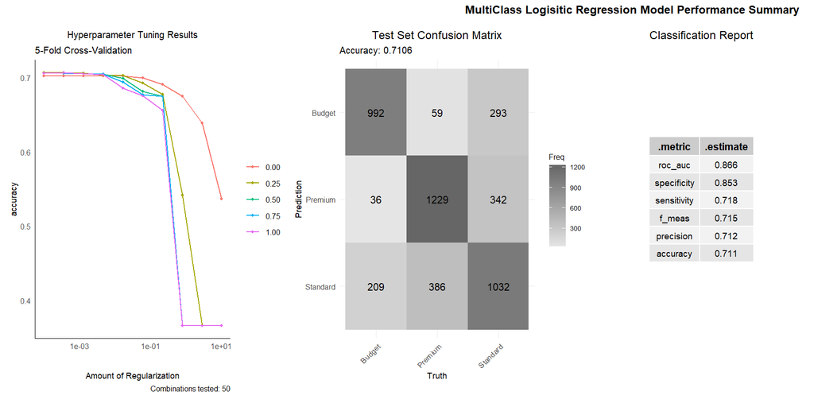

```r
# Get test predictions (class + probabilities)
test_predictions <- predict(final_mlr_fit, df_test) %>%
  bind_cols(predict(final_mlr_fit, df_test, type = "prob")) %>%
  bind_cols(df_test %>% select(price_tier))

# Compute metrics (using yardstick explicitly to avoid caret conflicts)
test_accuracy <- yardstick::accuracy(test_predictions, truth = price_tier, estimate = .pred_class)
test_sensitivity <- yardstick::sensitivity(test_predictions, truth = price_tier, estimate = .pred_class, estimator = "macro")
test_specificity <- yardstick::specificity(test_predictions, truth = price_tier, estimate = .pred_class, estimator = "macro")
test_precision <- yardstick::precision(test_predictions, truth = price_tier, estimate = .pred_class, estimator = "macro")
test_f1 <- yardstick::f_meas(test_predictions, truth = price_tier, estimate = .pred_class, estimator = "macro")

# Get probability columns for multiclass ROC AUC
prob_cols <- names(test_predictions)[stringr::str_detect(names(test_predictions), "^\\.pred_")]
prob_cols <- prob_cols[prob_cols != ".pred_class"]

test_roc_auc <- yardstick::roc_auc(test_predictions, truth = price_tier, all_of(prob_cols), estimator = "macro")

# Combine all metrics into a single summary table
test_metrics <- dplyr::bind_rows(
  test_accuracy,
  test_sensitivity,
  test_specificity,
  test_precision,
  test_f1,
  test_roc_auc
) %>%
  dplyr::select(.metric, .estimate) %>%
  dplyr::arrange(desc(.estimate))

# Display the summary
#print(test_metrics)

# Confusion matrix (heatmap visualization)
test_conf_mat <- yardstick::conf_mat(test_predictions, truth = price_tier, estimate = .pred_class)

p5 <- autoplot(test_conf_mat, type = "heatmap") +
  labs(
    title = "Test Set Confusion Matrix",
    subtitle = paste("Accuracy:", round(test_accuracy$.estimate, 4))
  ) +
  theme_minimal(base_size=10) +
  theme(
    plot.title = element_text(hjust = 0.5, size = 12),
    axis.title = element_text(size = 9),
    axis.text = element_text(size = 8),
    axis.text.x = element_text(angle = 45, hjust = 1),
    legend.title = element_text(size = 8),
    legend.text = element_text(size = 7)
  )

# Round estimates for readability
metrics_table <- test_metrics %>%
  arrange(desc(.estimate)) %>%
  mutate(.estimate = round(.estimate, 3))

# Create ggplot table
table_plot <- ggplot() +
  annotation_custom(
    grob = tableGrob(
      metrics_table,
      rows = NULL,          # removes row names
      theme = ttheme_default(
        core = list(fg_params = list(cex = 0.8)),   # text size
        colhead = list(fg_params = list(cex = 0.9, fontface = "bold"))
      )
    )
  ) +
  theme_void() +
  labs(title = "Classification Report") +
  theme(
    plot.title = element_text(
      size = 12,
      hjust = 0.5,
      margin = margin(b = 5)
    ),
    plot.subtitle = element_text(
      size = 11,
      hjust = 0.5,
      margin = margin(b = 10)
    ),
    plot.margin = margin(10, 10, 10, 10)
  )

# Print the table
( p1 | p5 | table_plot) +
  plot_layout(ncol = 3, widths = c(1, 1, 1)) +
  plot_annotation(
    title = "MultiClass Logisitic Regression Model Performance Summary",
    theme = theme(
      plot.title = element_text(size = 12, face = "bold", hjust = 1)
    )
  )
```

- Here, we see from the metrics table that even with the optimal hyperparameter and regularization, we see an accuracy of only 71% and a f1-score of 71% for the test data. This shows that the model does perform modestly but can be improved on even further.
- We also see that the model has a specificity of 85%, which shows that the model performs decently when identifying false classes for a test input, but falters to a 71% sensitivity when it has to correctly identify the correct class for the test data. This shows that the model is not a confident price tier identifier for new data, but it is a good false positive alarm.

## 5.5 XGBoost Model Implementation

- We trained the model on the top 15 features and see from the validation loss curve (plateauing) that the model is not overfitting. From the confusion matrix we see expectedly, that model confuses less between budget and premium category. The Recall, Precision and F1 scores are strong showing good confidence in model’s predictive power.

```r
# ============================================================================
# SETUP AND CONFIGURATION
# ============================================================================
# Load required libraries for modeling, visualization, and evaluation
library(xgboost)                    # Gradient boosting framework
library(dplyr)                      # Data manipulation
library(ggplot2)                    # Visualization
library(tidyr)                      # Data reshaping
library(caret)                      # Confusion matrix and evaluation metrics
library(gt)                         # Publication-ready tables
library(scales)                     # Color scales for plots
library(ParBayesianOptimization)    # Bayesian hyperparameter tuning
library(gridExtra)                  # Load gridExtra for table visualization
library(patchwork)                  # Combine multiple plots

# Set random seed for reproducibility across all operations
set.seed(42)

# ============================================================================
# DATA LOADING AND PREPROCESSING
# ============================================================================
# Load training dataset from CSV file
df <- read.csv("df_train_sub.csv", stringsAsFactors = FALSE)

# Separate target variable (price_tier) from predictor features
# Ensure target is a factor and trim any whitespace
target <- factor(trimws(df$price_tier))
features <- df %>% select(-price_tier)

# Convert to numeric matrices required by XGBoost
# XGBoost requires numeric labels starting from 0
X <- as.matrix(features)
y <- as.numeric(target) - 1  # Convert factor levels (1,2,3...) to (0,1,2...)

# Create DMatrix object - XGBoost's internal data structure for efficiency
dtrain <- xgb.DMatrix(data = X, label = y)

# ============================================================================
# FEATURE IMPORTANCE ANALYSIS
# ============================================================================
# Configuration: Number of top features to display in visualization
TOP_N_FEATURES <- 15

# Train a preliminary model to assess feature importance
# This is a quick model with minimal rounds to get initial feature rankings
quick_model <- xgb.train(
  data = dtrain,
  booster = "gbtree",                              # Tree-based boosting
  objective = "multi:softprob",                    # Multi-class classification with probabilities
  num_class = length(unique(y)),                   # Number of target classes
  nrounds = 50,                                    # Moderate number of iterations
  eval_metric = "mlogloss",                        # Multi-class log loss
  verbose = 0                                      # Suppress training output
)

# Extract feature importance scores based on information gain
# Gain: Total reduction in loss when feature is used for splitting
importance_matrix <- xgb.importance(
  feature_names = colnames(X),
  model = quick_model
)

# Select top N most important features for visualization
importance_df <- importance_matrix[1:TOP_N_FEATURES, ]
# Reverse factor levels for proper ordering in horizontal bar chart
importance_df$Feature <- factor(
  importance_df$Feature,
  levels = rev(importance_df$Feature)
)

# Create horizontal bar chart of feature importances
p1 <- ggplot(importance_df, aes(x = Feature, y = Gain, fill = Gain)) +
  geom_col() +
  coord_flip() +  # Horizontal bars for better label readability
  scale_fill_gradient(low = "#FFDDC1", high = "#FF5733") +
  labs(
    title = paste("Top", TOP_N_FEATURES, "Feature Importances"),
    x = "Feature",
    y = "Importance (Gain)"
  ) +
  theme_minimal(base_size = 10) +  # Reduced base size for grid layout
  theme(
    legend.position = "none",
    plot.title = element_text(face = "bold", hjust = 0.5, size = 16),
    axis.title = element_text(size = 9),
    axis.text = element_text(size = 8),
    panel.grid = element_blank()
  )

# ============================================================================
# FEATURE SELECTION
# ============================================================================
# Define final feature set for model training
# Selected based on domain knowledge and importance analysis
train_features <- c(
  "room_type",                    # Type of accommodation
  "bedrooms",                     # Number of bedrooms
  "longitude",                    # Geographic coordinate
  "accommodates",                 # Maximum guest capacity
  "latitude",                     # Geographic coordinate
  "availability_flexibility",     # Booking flexibility score
  "review_stability",             # Review consistency metric
  "bathrooms",                    # Number of bathrooms
  "cleaning_fee",                 # Cleaning fee amount
  "extra_people",                 # Fee per additional guest
  "property_type",                # Property category
  "calendar_updated",             # Recency of calendar updates
  "amenities",                    # Number/quality of amenities
  "number_of_reviews",            # Total review count
  "guests_included"               # Base number of included guests
)

# Extract selected features and recreate matrices
features <- df[, train_features]
X <- as.matrix(features)

# Recreate DMatrix with reduced feature set
dtrain <- xgb.DMatrix(data = X, label = y)

# ============================================================================
# HYPERPARAMETER OPTIMIZATION (BAYESIAN OPTIMIZATION)
# ============================================================================
# Define objective function for Bayesian optimization
# This function evaluates a set of hyperparameters via cross-validation
# Returns: negative log loss (for maximization) and optimal number of rounds
scoringFunction <- function(eta, max_depth, gamma, colsample_bytree,
                           min_child_weight, subsample) {

  # Progress tracking during optimization
  cat("Testing: eta =", eta, "| max_depth =", max_depth, "\n")
  flush.console()

  # Configure XGBoost parameters for current evaluation
  params <- list(
    booster = "gbtree",                            # Tree-based model
    objective = "multi:softprob",                  # Multi-class probabilities
    num_class = length(unique(y)),                 # Number of classes
    eval_metric = "mlogloss",                      # Evaluation metric
    eta = eta,                                     # Learning rate (shrinkage)
    max_depth = as.integer(max_depth),            # Maximum tree depth
    gamma = gamma,                                 # Min loss reduction for split
    colsample_bytree = colsample_bytree,          # Feature sampling per tree
    min_child_weight = min_child_weight,          # Min sum of weights in leaf
    subsample = subsample,                         # Row sampling per tree
    nthread = 6                                    # Parallel threads
  )
```

```r
  # Perform 3-fold stratified cross-validation
  cv <- xgb.cv(
    params = params,
    data = dtrain,
    nrounds = 300,                                 # Max boosting rounds
    nfold = 3,                                     # Number of CV folds
    stratified = TRUE,                             # Maintain class distribution
    verbose = 0,                                   # Suppress output
    early_stopping_rounds = 3                      # Stop if no improvement
  )

  # Return negative log loss (Bayesian opt maximizes, we want to minimize loss)
  list(
    Score = -min(cv$evaluation_log$test_mlogloss_mean),
    nrounds = cv$best_iteration
  )
}

# Define hyperparameter search space bounds
bounds <- list(
  eta = c(0.01, 0.05),                    # Learning rate range
  max_depth = c(3L, 6L),                  # Tree depth range
  gamma = c(0, 5),                        # Regularization parameter
  colsample_bytree = c(0.5, 1.0),        # Feature sampling ratio
  min_child_weight = c(2, 5),            # Minimum leaf weight
  subsample = c(0.5, 1.0)                # Row sampling ratio
)

# Execute Bayesian optimization
# Uses Gaussian Process to intelligently explore hyperparameter space
opt_result <- bayesOpt(
  FUN = scoringFunction,
  bounds = bounds,
  initPoints = 10,                        # Random initialization points
  iters.n = 20,                           # Optimization iterations
  acq = "ei"                              # Expected Improvement acquisition
)

# Extract and display best hyperparameters found
best_params <- getBestPars(opt_result)
print(best_params)

# Save optimization results for future use
saveRDS(opt_result, file = "opt_result_sub.rds")

# ============================================================================
# FINAL MODEL TRAINING
# ============================================================================
# Load previously optimized hyperparameters
opt_result <- readRDS("opt_result_sub.rds")
best_params <- getBestPars(opt_result)

# Create train/validation split (80/20)
set.seed(42)
train_idx <- sample(seq_len(nrow(X)), size = 0.8 * nrow(X))

# Split features and labels
X_train <- X[train_idx, ]
y_train <- y[train_idx]
X_val   <- X[-train_idx, ]
y_val   <- y[-train_idx]

# Create DMatrix objects for training and validation sets
dtrain <- xgb.DMatrix(data = X_train, label = y_train)
dval   <- xgb.DMatrix(data = X_val, label = y_val)

# Set up watchlist to monitor performance on both sets during training
watchlist <- list(train = dtrain, eval = dval)

# Train final model with optimized hyperparameters
final_model <- xgb.train(
  params = list(
    booster = "gbtree",
    objective = "multi:softprob",
    num_class = length(unique(y)),
    eval_metric = "mlogloss",
    eta = best_params$eta,
    max_depth = best_params$max_depth,
    gamma = best_params$gamma,
    colsample_bytree = best_params$colsample_bytree,
    min_child_weight = best_params$min_child_weight,
    subsample = best_params$subsample
  ),
  data = dtrain,
  nrounds = 300,                          # Maximum training rounds
  watchlist = watchlist,                  # Track train and validation metrics
  verbose = 1,                            # Show progress
  print_every_n = 100                     # Print every 100 rounds
)

# Save trained model to disk
xgb.save(final_model, "xgb_trained_model.model")

# ============================================================================
# TRAINING VISUALIZATION
# ============================================================================
# Extract training history from model
log_df <- as.data.frame(final_model$evaluation_log)

# Identify best iteration (minimum validation loss)
best_iter <- which.min(log_df$eval_mlogloss)
best_loss <- log_df$eval_mlogloss[best_iter]

# Detect plateau point (no improvement for 10 consecutive rounds)
# This helps identify when early stopping should have occurred
plateau_iter <- NA
for (i in seq(best_iter, nrow(log_df) - 10)) {
  if (all(log_df$eval_mlogloss[i:(i + 9)] > log_df$eval_mlogloss[i - 1])) {
    plateau_iter <- i
    break
  }
}

# Create learning curve plot
p2 <- ggplot(log_df, aes(x = iter)) +
  geom_line(aes(y = train_mlogloss, color = "Train"), linewidth = 0.8) +
  geom_line(aes(y = eval_mlogloss, color = "Validation"), linewidth = 0.8) +
  # Mark best iteration with vertical line
  geom_vline(
    xintercept = best_iter,
    linetype = "dashed",
    color = "darkgreen",
    linewidth = 0.8
  ) +
  # Highlight best point
  geom_point(
    data = data.frame(iter = best_iter, loss = best_loss),
    aes(x = iter, y = loss),
    color = "darkgreen",
    size = 2
  ) +
  annotate(
    "text",
    x = best_iter, y = best_loss,
    label = paste("Best:", best_iter),
    hjust = -0.1, vjust = 1.2,
    color = "darkgreen",
    size = 3
  ) +
  labs(
    title = "Training vs Validation Log Loss",
    x = "Iteration",
    y = "Log Loss"
  ) +
  scale_color_manual(values = c("Train" = "#FF5733", "Validation" = "#1E90FF")) +
  theme_minimal(base_size = 10) +  # Reduced base size for grid layout
  theme(
    plot.title = element_text(face = "bold", hjust = 0.5, size = 16),
    legend.title = element_blank(),
    legend.text = element_text(size = 8),
    axis.title = element_text(size = 9),
    axis.text = element_text(size = 8),
    axis.line = element_line(color = "black"),
    panel.grid = element_blank()
  )

# ============================================================================
# MODEL EVALUATION ON TEST SET
# ============================================================================
# Load trained model from disk
loaded_model <- xgb.load("xgb_trained_model.model")

# Load test dataset
test_df <- read.csv("df_test_sub.csv", stringsAsFactors = FALSE)

# Extract same features used during training (critical for consistency)
features_test <- test_df[, train_features]
X_test <- as.matrix(features_test)

# Prepare true labels from test set
target_test <- factor(trimws(test_df$price_tier))
y_test <- as.numeric(target_test) - 1
```

[figure not shown]

```r
# Generate predictions on test set
dtest <- xgb.DMatrix(data = X_test)
pred_probs <- predict(loaded_model, dtest)

# Convert probability vector to class predictions
# pred_probs is returned as a flat vector, reshape to (n_samples x n_classes)
n_classes <- length(levels(target_test))
pred_matrix <- matrix(pred_probs, ncol = n_classes, byrow = TRUE)
pred_class <- max.col(pred_matrix) - 1  # Get class with highest probability

# Convert numeric predictions back to original factor labels
pred_labels <- factor(
  levels(target_test)[pred_class + 1],
  levels = levels(target_test)
)

# Generate confusion matrix and classification metrics
cm <- confusionMatrix(pred_labels, target_test)

# ============================================================================
# CONFUSION MATRIX VISUALIZATION
# ============================================================================
# Convert confusion matrix to data frame for plotting
cm_table <- as.data.frame(cm$table)
colnames(cm_table) <- c("Predicted", "Actual", "Freq")

# Create heatmap visualization of confusion matrix
p3 <- ggplot(cm_table, aes(x = Actual, y = Predicted, fill = Freq)) +
  geom_tile(color = "white", linewidth = 0.5) +
  geom_text(aes(label = Freq), size = 3.5, color = "black", fontface = "bold") +
  scale_fill_gradient(low = "white", high = "#1E90FF") +
  labs(
    title = "Confusion Matrix - Test Set",
    x = "Actual Price Tier",
    y = "Predicted Price Tier",
    fill = "Count"
  ) +
  theme_minimal(base_size = 10) +  # Reduced base size for grid layout
  theme(
    plot.title = element_text(hjust = 0.5, face = "bold", size = 16),
    axis.title = element_text(size = 9),
    axis.text = element_text(size = 8),
    axis.text.x = element_text(angle = 45, hjust = 1),
    legend.title = element_text(size = 8),
    legend.text = element_text(size = 7)
  )

# ============================================================================
# DETAILED CLASSIFICATION REPORT
# ============================================================================
# Extract confusion matrix as numeric matrix
cm_matrix <- as.matrix(cm$table)

# Set class labels for rows and columns
true_classes <- levels(target_test)
rownames(cm_matrix) <- true_classes
colnames(cm_matrix) <- true_classes

# Calculate per-class performance metrics
# For each class, compute Precision, Recall, and F1-Score
metrics_list <- lapply(true_classes, function(cls) {
  # Extract True/False Positives/Negatives for current class
  TP <- cm_matrix[cls, cls]                      # Correctly predicted as class
  FP <- sum(cm_matrix[cls, ]) - TP               # Incorrectly predicted as class
  FN <- sum(cm_matrix[, cls]) - TP               # Missed predictions for class
  TN <- sum(cm_matrix) - TP - FP - FN            # Correctly predicted as other

  # Calculate classification metrics
  Precision <- ifelse((TP + FP) == 0, 0, TP / (TP + FP))  # Correct among predicted
  Recall    <- ifelse((TP + FN) == 0, 0, TP / (TP + FN))  # Correct among actual
  F1        <- ifelse((Precision + Recall) == 0, 0,       # Harmonic mean
                     2 * Precision * Recall / (Precision + Recall))
  Support   <- TP + FN                                     # Total samples in class

  data.frame(
    Class = cls,
    Precision = Precision,
    Recall = Recall,
    F1 = F1,
    Support = Support
  )
})

# Combine per-class metrics into single data frame
metrics_df <- bind_rows(metrics_list)

# Calculate overall accuracy
total_support <- sum(metrics_df$Support)
overall_accuracy <- sum(diag(cm_matrix)) / sum(cm_matrix)

# Calculate macro average (unweighted mean across classes)
macro_avg <- metrics_df %>%
  summarise(
    Precision = mean(Precision),
    Recall = mean(Recall),
    F1 = mean(F1),
    Support = total_support
  ) %>%
  mutate(Class = "Macro Avg")

# Calculate weighted average (weighted by class support)
weighted_avg <- metrics_df %>%
  summarise(
    Precision = sum(Precision * Support) / total_support,
    Recall = sum(Recall * Support) / total_support,
    F1 = sum(F1 * Support) / total_support,
    Support = total_support
  ) %>%
  mutate(Class = "Weighted Avg")

wp_subhamay <- sum(metrics_df$Precision * metrics_df$Support) / total_support
wr_subhamay <- sum(metrics_df$Recall * metrics_df$Support) / total_support
wf_subhamay <- sum(metrics_df$F1 * metrics_df$Support) / total_support

# Combine all metrics into final report
report_df <- bind_rows(metrics_df, macro_avg, weighted_avg) %>%
  mutate(across(where(is.numeric), ~ round(., 4)))

# Format the data for display
display_df <- report_df %>%
  mutate(
    Precision = sprintf("%.4f", Precision),
    Recall = sprintf("%.4f", Recall),
    F1 = sprintf("%.4f", F1)
  )

# Create theme for table
table_theme <- ttheme_minimal(
  base_size = 10,
  core = list(
    fg_params = list(hjust = 0.5, x = 0.5, fontface = "plain"),
    bg_params = list(
      fill = c(rep(c("#F8F9FA", "#FFFFFF"), length.out = nrow(display_df) - 2),
               "#E8F4F8", "#E8F4F8")  # Light blue for summary rows
    )
  ),
  colhead = list(
    fg_params = list(fontface = "bold", fontsize = 11),
    bg_params = list(fill = "#1E90FF", col = "white")
  ),
  rowhead = list(
    fg_params = list(hjust = 0.5, x = 0.5, fontface = "plain")
  )
)

# Convert to ggplot table
p4 <- ggplot() +
  annotation_custom(
    grob = tableGrob(
      display_df,
      rows = NULL,
      theme = table_theme
    )
  ) +
  theme_void() +
  labs(
    title = "Classification Report",
    subtitle = paste("Overall Accuracy:", round(overall_accuracy, 4))
  ) +
  theme(
    plot.title = element_text(
      size = 16,
      face = "bold",
      hjust = 0.5,
      margin = margin(b = 5)
    ),
    plot.subtitle = element_text(
      size = 11,
      hjust = 0.5,
      face = "bold",
      margin = margin(b = 10)
    ),
    plot.margin = margin(10, 10, 10, 10)
  )

# ============================================================================
# COMBINED VISUALIZATION GRID
# ============================================================================
# Combine all visualizations into 2x2 grid using patchwork
# Layout: Feature Importance | Training Curves
#         Confusion Matrix   | Classification Report
(p1 | p2) / (p3 | p4) +
  plot_annotation(
    title = "XGBoost Model Performance Summary",
    theme = theme(
      plot.title = element_text(size = 20, face = "bold", hjust = 0.5)
    )
  )
```

# 6 Results

We evaluated five machine learning algorithms to answer our research question: To what extent can machine learning identify key differentiators between Budget, Standard, and Premium Airbnb listings in Melbourne?

```r
# Create a table comparing 5 models
model_eval <- tibble(
  Model = c("KNN", "SVM", "Random Forest", "MultiClass Logisitic Regression", "XGBoost"),

  # Hyperparameters as a string for readability
  Hyperparameters = c(
    "neighbors=45, dist_powe=1",
    "C=1, gamma=0.001, kernel='rbf'",
    "mtry=16, trees = 2000, min_n = 5",
    "alpha=0.01, l1_ratio=0.5",
    hyperparameters_subhamay
  ),

  Accuracy = c(0.710, 0.780, 0.763, 0.711, 0.762),
  F1_Score    = c(0.710, 0.765, 0.766, 0.715, 0.763),
  ROC_AUC   = c(0.825, 0.856, 0.910, 0.866, 0.904)
)

# Round metrics for readability
model_eval <- model_eval %>%
  mutate(
    Accuracy = round(Accuracy, 3),
    F1_Score    = round(F1_Score, 3),
    ROC_AUC        = round(ROC_AUC, 3)
  )

# Create GT table
model_eval %>%
  gt() %>%
  fmt_number(
    columns = vars(Accuracy, F1_Score, ROC_AUC),
    decimals = 3
  ) %>%
  cols_label(
    Model = "Model",
    Hyperparameters = "Hyperparameters",
    Accuracy = "Accuracy",
    F1_Score = "F1-Score",
    ROC_AUC = "ROC_AUC"
  ) %>%
  tab_options(
    table.font.size = 11,
    data_row.padding = px(4)
  ) %>%
  tab_style(
    style = cell_text(weight = "bold"),
    locations = cells_column_labels(everything())
  ) %>%
  opt_align_table_header("center")
```

| Model | Hyperparameters | Accuracy | F1-Score | ROC_AUC |
| --- | --- | --- | --- | --- |
| KNN | neighbors=45, dist_powe=1 | 0.710 | 0.710 | 0.825 |
| SVM | C=1, gamma=0.001, kernel='rbf' | 0.780 | 0.765 | 0.856 |
| Random Forest | mtry=16, trees = 2000, min_n = 5 | 0.763 | 0.766 | 0.910 |
| MultiClass Logisitic Regression | alpha=0.01, l1_ratio=0.5 | 0.711 | 0.715 | 0.866 |
| XGBoost | eta=0.05, max_depth=6.00, gamma=0.00, colsample_bytree=0.90, min_child_weight=4.14, subsample=0.50 | 0.762 | 0.763 | 0.904 |

Machine learning models successfully identified price tier differentiators with a classification accuracy of 78 percent. The Support Vector Machine (SVM) achieved the best overall performance, reaching 78.0 percent accuracy. The Random Forest model exhibited the strongest discrimination capability with a 91.0 percent ROC AUC, indicating excellent ability to distinguish between tiers, and also provided the most balanced performance with a 76.6 percent F1-score, reflecting a solid precision-recall balance. All models substantially outperformed the random guessing baseline of 33.3 percent for three classes. Overall, the 78 percent accuracy demonstrates that machine learning can reliably identify price tier patterns, highlighting its potential for practical real-world applications. The performance gap between the SVM (78 percent accuracy) and k-NN (71 percent accuracy) further suggests that capturing non-linear relationships and effectively handling high-dimensional data are key factors in achieving superior results.

### 6.0.1 Conclusion

The most influential factors in determining price tiers are primarily property-related, accounting for 81 percent of the model’s overall importance. The top three property characteristics are room type (entire home versus private room), capacity features such as the number of guests accommodated, bedrooms, and beds, and pricing structure elements including cleaning fees and guest policies. Interestingly, host characteristics—such as tenure, superhost status, and response rate—contribute only 5 percent to total importance. This finding suggests that new hosts can effectively compete in premium market segments by prioritizing property quality and amenities rather than relying on long-term experience or reputation.

Machine learning successfully answers our research question: We can identify price tier differentiators with 78% accuracy, and the most influential drivers are property capacity, room type, and amenities—not host experience. This finding democratizes the premium market for new hosts and provides actionable insights for Australia’s $4.8B short-term rental industry. The practical implication is clear: hosts should invest in property quality (bedrooms, amenities, capacity) rather than waiting years to build reputation. For a competitive market facing -12% occupancy declines in Sydney, these data-driven insights enable strategic decision-making that can directly impact revenue optimization.

### 6.0.2 Limitations and Future work

This study has several limitations that should be noted. Its geographic scope is restricted to a single city, Melbourne, which means the findings may not generalize to other cities such as Sydney or to regional areas. The temporal scope covers only one point in time (December 2018), so seasonal patterns and market fluctuations are not captured. Review sentiment was not incorporated, which would require natural language processing; and neighborhood-level details such as walkability or transit accessibility were unavailable.

Future work can address these gaps through several directions. Expanding the geographic scope to cities like Sydney and Brisbane would help assess generalizability, while analyzing multi-year data could reveal seasonal and longitudinal market trends. More advanced extensions include applying deep learning (using convolutional neural networks) to extract visual quality signals from property photos, using NLP-based sentiment analysis on reviews and descriptions, implementing causal inference via A/B testing to measure the true return on investment of amenity enhancements, and adopting dynamic modeling frameworks to update price tier predictions in real time based on market demand.

# 7 Appendices

## 7.1 References

OpenML. (n.d.). Data set with ID 46807 [Data set]. OpenML. Retrieved September 21, 2025, from https://www.openml.org/search?type=data&sort=runs&id=46807&status=active

TylerX. (n.d.). Melbourne Airbnb open data [Data set]. Kaggle. Retrieved September 21, 2025, from https://www.kaggle.com/datasets/tylerx/melbourne-airbnb-open-data

Inside Airbnb. (n.d.). Inside Airbnb: Adding data to the debate. Retrieved September 21, 2025, from https://insideairbnb.com/

Shi, X., Mueller, J., Erickson, N., Li, M., & Smola, A. J. (2021). Benchmarking multimodal AutoML for tabular data with text fields. arXiv. https://doi.org/10.48550/arXiv.2111.02705

## 7.2 Data Dictionary of cleaned dataset

```r
library(tidyverse)
library(knitr)
library(kableExtra)
library(tidymodels)
library(tibble)


airbnb_data <- read.csv("dataset_cleaned.csv")

data_dict <- data.frame(
  Type = sapply(airbnb_data, function(x) base::class(x)[1]),
  # Description = "",  # You can fill this manually if desired
  Range = sapply(airbnb_data, function(x) {
    if(is.numeric(x)) {
      paste0(min(x, na.rm = TRUE), " - ", max(x, na.rm = TRUE))
    } else if(is.factor(x) || is.character(x)) {
      paste(head(unique(x), 5), collapse = ", ")  # show first 5 unique values
    } else {
      ""
    }
  }),
  stringsAsFactors = FALSE
)

# Display nicely
kable(data_dict) %>%
  kable_styling(bootstrap_options = "striped", full_width = FALSE)
```

|  | Type | Range |
| --- | --- | --- |
| id | integer | 9835 - 30593623 |
| host_response_time | character | within an hour, a day or more, within a few hours |
| host_is_superhost | logical |  |
| host_has_profile_pic | logical |  |
| host_identity_verified | logical |  |
| neighborhood | character | St Kilda, Central Business District, Richmond, Carlton North, Southbank |
| property_type | character | Apartment, House, Condominium, Townhouse, Loft |
| room_type | character | Entire home/apt, Private room, Shared room |
| accommodates | integer | 1 - 16 |
| bathrooms | numeric | 0 - 14 |
| bedrooms | integer | 0 - 16 |
| beds | integer | 0 - 24 |
| bed_type | character | Real Bed, Pull-out Sofa, Airbed, Futon, Couch |
| price | integer | 0 - 12501 |
| security_deposit | integer | 0 - 6950 |
| cleaning_fee | integer | 0 - 867 |
| guests_included | integer | 1 - 16 |
| extra_people | integer | 0 - 421 |
| minimum_nights | integer | 1 - 1125 |
| maximum_nights | integer | 1 - 99999999 |
| availability_30 | integer | 0 - 30 |
| availability_60 | integer | 0 - 60 |
| availability_90 | integer | 0 - 90 |
| availability_365 | integer | 0 - 365 |
| instant_bookable | logical |  |
| cancellation_policy | character | flexible, strict_14_with_grace_period, moderate, super_strict_30, super_strict_60 |
| require_guest_profile_picture | logical |  |
| require_guest_phone_verification | logical |  |
| calculated_host_listings_count | integer | 1 - 98 |
| price_label | integer | 0 - 9 |
| E_detail_len | integer | 166 - 4493 |
| E_house_rules | integer | 1 - 1000 |
| E_transit_near_southern_cross | logical |  |
| E_transit_free_tram_zone | logical |  |
| E_transit_airport_bus | logical |  |
| E_transit_tram_nearby | logical |  |
| E_transit_train_nearby | logical |  |
| E_transit_bus_nearby | logical |  |
| E_transit_uber_taxi | logical |  |
| E_transit_parking_available | logical |  |
| E_transit_walk_proximity | logical |  |
| E_has_private_access | logical |  |
| E_has_pool | logical |  |
| E_has_kitchen | logical |  |
| E_has_wifi | logical |  |
| E_has_linen | logical |  |
| E_host_present | logical |  |
| E_self_checkin | logical |  |
| E_full_privacy | logical |  |
| E_concierge_available | logical |  |
| E_contactable | logical |  |
| E_total_amenities | integer | 1 - 94 |
| E_review_span_m | integer | 1 - 101 |
| E_review_volume | numeric | 0.01 - 535.44 |
| E_review_scores_rating_x_response | numeric | 0 - 100 |
| E_host_tenure_y | numeric | 6.77260273972603 - 16.6246575342466 |
| E_host_response_rate | integer | 0 - 100 |
| E_host_num_verifications | integer | 0 - 12 |
| E_host_has_social_verif | logical |  |
| E_host_has_govt_verif | logical |  |
| E_calendar_updated_d | integer | 0 - 2490 |

```r
# -------------------------------
# Summary statistics
# -------------------------------
num_samples <- nrow(airbnb_data)
num_features <- ncol(airbnb_data) - 1  # exclude target
num_price_categories <- length(unique(airbnb_data$price_label))
num_numeric <- sum(sapply(airbnb_data, is.numeric))
num_factor <- sum(sapply(airbnb_data, is.factor))

overview_df <- data.frame(
  Metric = c("Number of Samples", "Number of Features", "Price Categories",
             "Numeric Columns", "Factor Columns"),
  Value = c(num_samples, num_features, num_price_categories, num_numeric, num_factor)
)

# Display table
kable(overview_df)
```

| Metric | Value |
| --- | --- |
| Number of Samples | 18316 |
| Number of Features | 60 |
| Price Categories | 10 |
| Numeric Columns | 28 |
| Factor Columns | 0 |

```r
# -------------------------------
# Summarize Range and Unique Values
# -------------------------------
summary_report <- data.frame(
  data_type = sapply(airbnb_data, base::class),
  range = NA,
  unique_values = NA,
  stringsAsFactors = FALSE
)

# Fill in values
for (i in seq_along(airbnb_data)) {
  col <- airbnb_data[[i]]
  col_type <- base::class(col)
  unique_vals <- sort(unique(col))

  # Logical columns
  if (is.logical(col)) {
    summary_report$range[i] <- "0-1"
    summary_report$unique_values[i] <- length(unique_vals)

  # Numeric columns
  } else if (is.numeric(col) || is.integer(col)) {
      summary_report$range[i] <- paste0(min(col, na.rm = TRUE), "-", max(col, na.rm = TRUE))
      summary_report$unique_values[i] <- length(unique_vals)

  # Character/factor columns
  } else if (is.factor(col) || is.character(col)) {
    summary_report$range[i] <- NA
    summary_report$unique_values[i] <- length(unique_vals)
  }
}

# Display nicely
kable(summary_report)
```

|  | data_type | range | unique_values |
| --- | --- | --- | --- |
| id | integer | 9835-30593623 | 18316 |
| host_response_time | character | NA | 3 |
| host_is_superhost | logical | 0-1 | 2 |
| host_has_profile_pic | logical | 0-1 | 2 |
| host_identity_verified | logical | 0-1 | 2 |
| neighborhood | character | NA | 59 |
| property_type | character | NA | 34 |
| room_type | character | NA | 3 |
| accommodates | integer | 1-16 | 16 |
| bathrooms | numeric | 0-14 | 20 |
| bedrooms | integer | 0-16 | 13 |
| beds | integer | 0-24 | 20 |
| bed_type | character | NA | 5 |
| price | integer | 0-12501 | 425 |
| security_deposit | integer | 0-6950 | 183 |
| cleaning_fee | integer | 0-867 | 226 |
| guests_included | integer | 1-16 | 14 |
| extra_people | integer | 0-421 | 92 |
| minimum_nights | integer | 1-1125 | 63 |
| maximum_nights | integer | 1-99999999 | 189 |
| availability_30 | integer | 0-30 | 31 |
| availability_60 | integer | 0-60 | 61 |
| availability_90 | integer | 0-90 | 91 |
| availability_365 | integer | 0-365 | 366 |
| instant_bookable | logical | 0-1 | 2 |
| cancellation_policy | character | NA | 6 |
| require_guest_profile_picture | logical | 0-1 | 2 |
| require_guest_phone_verification | logical | 0-1 | 2 |
| calculated_host_listings_count | integer | 1-98 | 51 |
| price_label | integer | 0-9 | 10 |
| E_detail_len | integer | 166-4493 | 3228 |
| E_house_rules | integer | 1-1000 | 932 |
| E_transit_near_southern_cross | logical | 0-1 | 2 |
| E_transit_free_tram_zone | logical | 0-1 | 2 |
| E_transit_airport_bus | logical | 0-1 | 2 |
| E_transit_tram_nearby | logical | 0-1 | 2 |
| E_transit_train_nearby | logical | 0-1 | 2 |
| E_transit_bus_nearby | logical | 0-1 | 2 |
| E_transit_uber_taxi | logical | 0-1 | 2 |
| E_transit_parking_available | logical | 0-1 | 2 |
| E_transit_walk_proximity | logical | 0-1 | 2 |
| E_has_private_access | logical | 0-1 | 2 |
| E_has_pool | logical | 0-1 | 2 |
| E_has_kitchen | logical | 0-1 | 2 |
| E_has_wifi | logical | 0-1 | 2 |
| E_has_linen | logical | 0-1 | 2 |
| E_host_present | logical | 0-1 | 2 |
| E_self_checkin | logical | 0-1 | 2 |
| E_full_privacy | logical | 0-1 | 2 |
| E_concierge_available | logical | 0-1 | 2 |
| E_contactable | logical | 0-1 | 2 |
| E_total_amenities | integer | 1-94 | 81 |
| E_review_span_m | integer | 1-101 | 95 |
| E_review_volume | numeric | 0.01-535.44 | 4064 |
| E_review_scores_rating_x_response | numeric | 0-100 | 409 |
| E_host_tenure_y | numeric | 6.77260273972603-16.6246575342466 | 2743 |
| E_host_response_rate | integer | 0-100 | 57 |
| E_host_num_verifications | integer | 0-12 | 13 |
| E_host_has_social_verif | logical | 0-1 | 2 |
| E_host_has_govt_verif | logical | 0-1 | 2 |
| E_calendar_updated_d | integer | 0-2490 | 68 |